# Demand Forecasting for A Fast-Food Restaurant Chain

Bowen Zhang, CID 02108549

March 13, 2022

# Project Description

This project is to forecast the daily demand for lettuce in each fast-food restaurant in different location. The dataset for this project is provided by the largest fast-food chain in United State, which contains multiple dataset for the whole supply chain operation. The data record is from 2015/03 to 2015/06, and we are going to build model and forecasting the next 14 days demand in each store by using Holt-Winters, ETS and ARIMA methods and to find an optimal forecasting method for each store.

There are 4 stores involve in total:  
1. Store 46673: Berkeley, California  
2. Store 4904: Berkeley, California  
3. Store 12631: Ridgewood, New York  
4. Store 20974: Elmhurst, New York

# Data Process

In order to forecast the demand for one specific ingredient of the four individual restaurants. We will manipulate and then process different data frame.

```r
store_4904 <- aggregate(Lettuce_Quantity ~ date, sum, data = total_menu[total_menu$StoreNumber == 4904, c(15, 21)])
store_12631 <- aggregate(Lettuce_Quantity ~ date, sum, data = total_menu[total_menu$StoreNumber == 12631, c(15,21)])
store_20974 <- aggregate(Lettuce_Quantity ~ date, sum, data = total_menu[total_menu$StoreNumber == 20974, c(15,21)])
store_46673 <- aggregate(Lettuce_Quantity ~ date, sum, data = total_menu[total_menu$StoreNumber == 46673, c(15,21)])
kable(list(head(store_4904, 5), head(store_12631, 5), head(store_20974, 5), head(store_46673, 5)),
      caption = 'First 5 Days of Data for Store 4904, 12631, 20974 and 46673') %>%
  kable_styling()
```

First 5 Days of Data for Store 4904, 12631, 20974 and 46673

| date | Lettuce_Quantity |
| --- | --- |
| 15-03-13 | 176 |
| 15-03-14 | 182 |
| 15-03-15 | 347 |
| 15-03-16 | 400 |
| 15-03-17 | 406 |

| date | Lettuce_Quantity |
| --- | --- |
| 15-03-05 | 232 |
| 15-03-06 | 227 |
| 15-03-07 | 181 |
| 15-03-08 | 221 |
| 15-03-09 | 229 |

| date | Lettuce_Quantity |
| --- | --- |
| 15-03-06 | 4 |
| 15-03-10 | 0 |
| 15-03-13 | 29 |
| 15-03-16 | 6 |
| 15-03-17 | 8 |

| date | Lettuce_Quantity |
| --- | --- |
| 15-03-05 | 152 |
| 15-03-06 | 100 |
| 15-03-07 | 54 |
| 15-03-08 | 199 |
| 15-03-09 | 166 |

*Table 1.1:* *This table provides the first 5 days’ lettuce use in each store.*

# Exploratory Data Analysis (EDA)

The purpose of this EDA was to obtain an overview of each store’s data before beginning further analysis and modeling. I conducted a statistical analysis for each day’s quantity variable and the general time series plot. Summary statistics can be found in the following table:

```r
summary(store_4904$Lettuce_Quantity)
```

```
##    Min. 1st Qu.  Median    Mean 3rd Qu.    Max.
##   162.0   267.0   341.0   327.9   383.0   449.0
```

```r
summary(store_12631$Lettuce_Quantity)
```

```
##    Min. 1st Qu.  Median    Mean 3rd Qu.    Max.
##   153.0   232.0   251.0   261.3   281.0   376.0
```

```r
summary(store_20974$Lettuce_Quantity)
```

```
##    Min. 1st Qu.  Median    Mean 3rd Qu.    Max.
##     0.0   175.0   222.0   206.2   250.0   386.0
```

```r
summary(store_46673$Lettuce_Quantity)
```

```
##    Min. 1st Qu.  Median    Mean 3rd Qu.    Max.
##    50.0   108.0   152.0   145.4   180.0   244.0
```

*Table 1.2:* *This table provides the summary statistics for the lettuce quantity in each store.*

### Exploratory Data Analysis (EDA) for store 4904

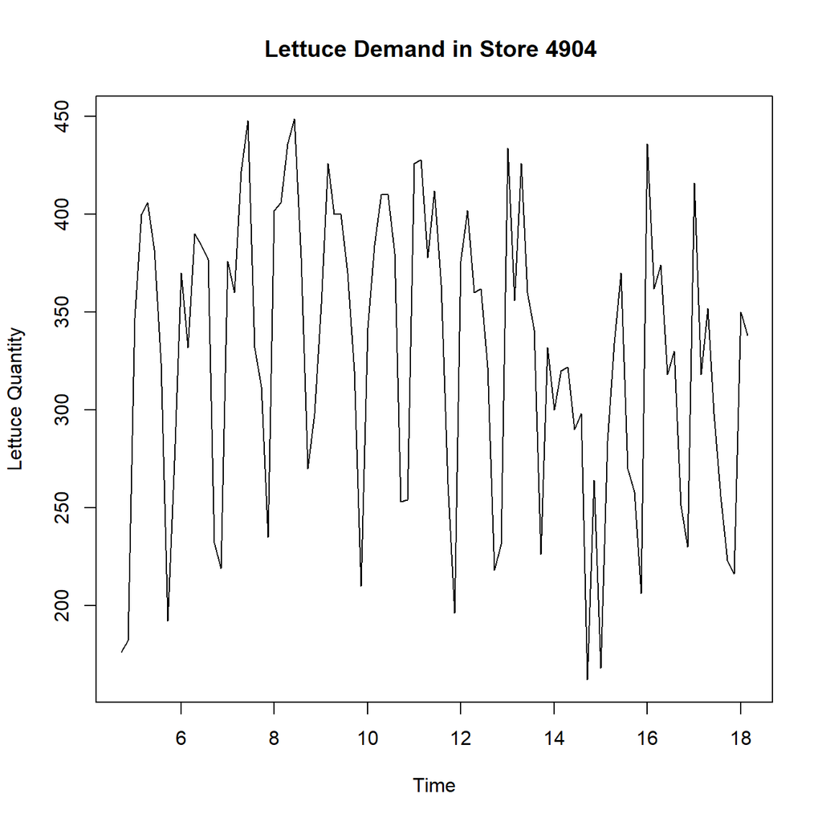

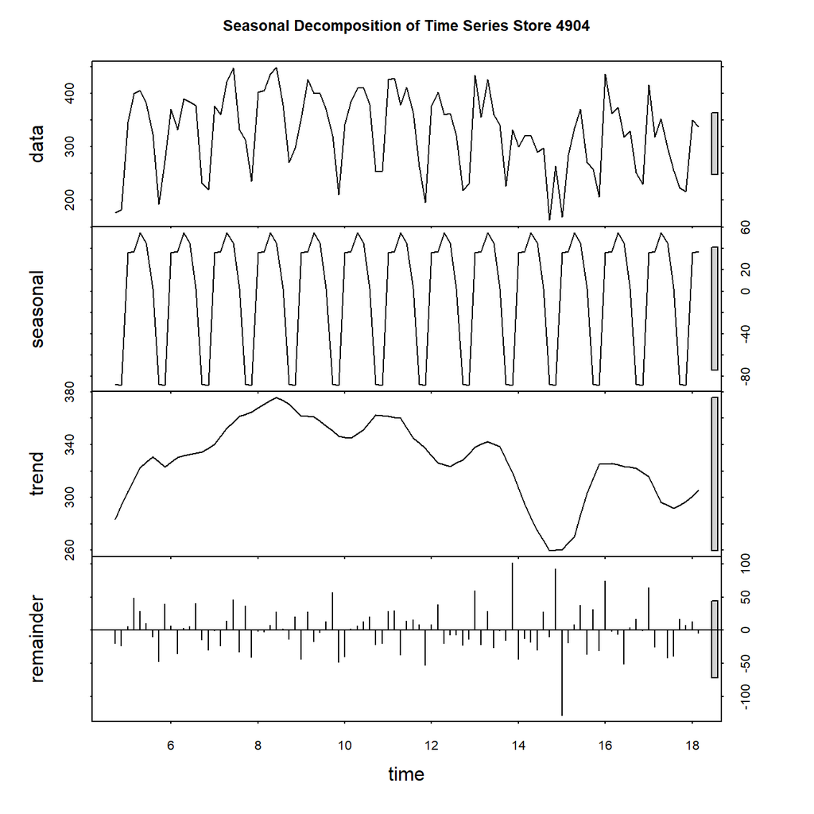

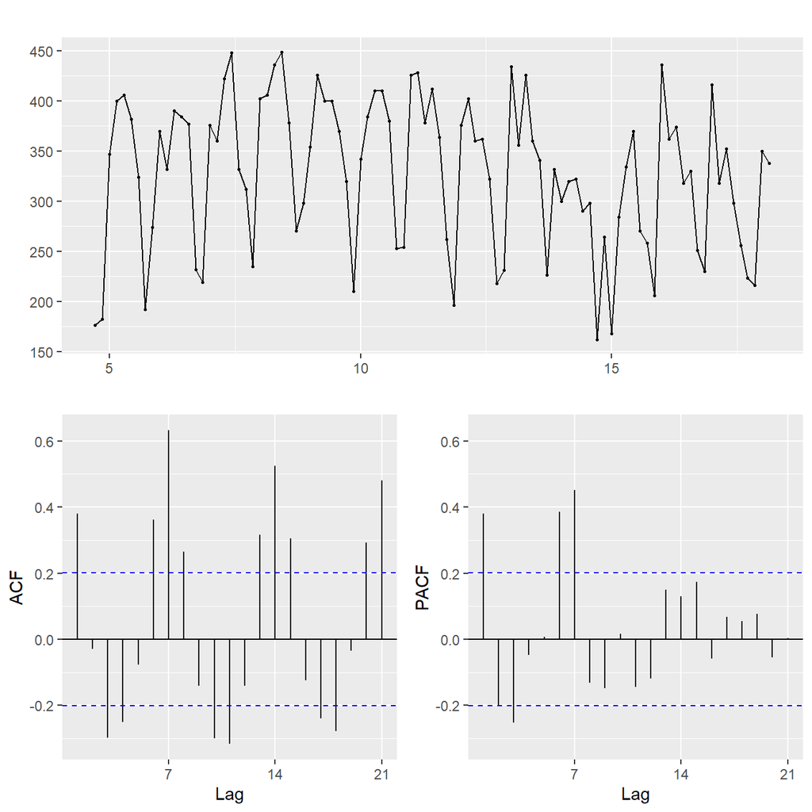

*Figure 1-a:* *This figure provides the general time series plot for store 4904.* *Figure 1-b:* *This figure provides the seasonal trend for store 4904.* *Figure 1-c:* *This figure provides the ACF and PACF plot for store 4904.*

From the figure above, we can see that the time series plot satisfied the assumptions for time series, and the second plot indicates seasonal trends for the quantity.

### Exploratory Data Analysis (EDA) for store 20974

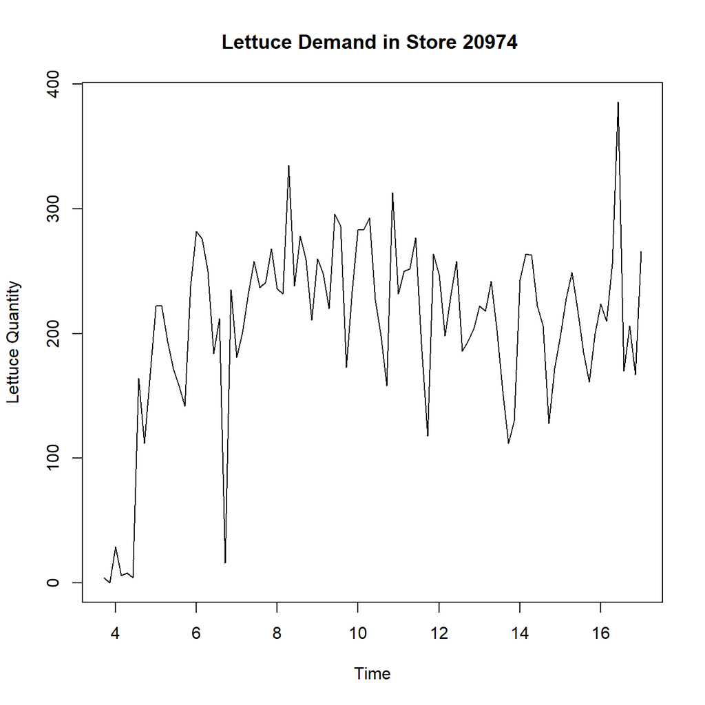

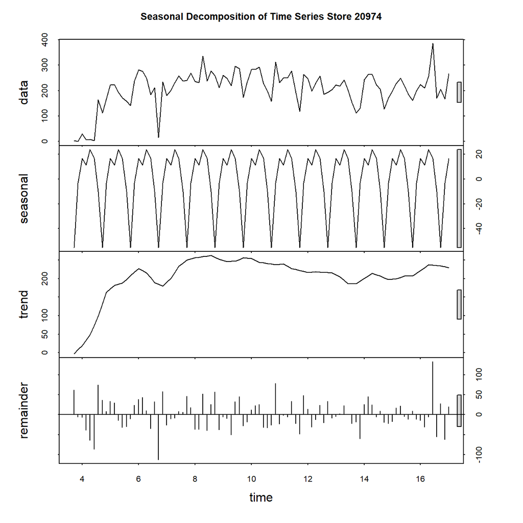

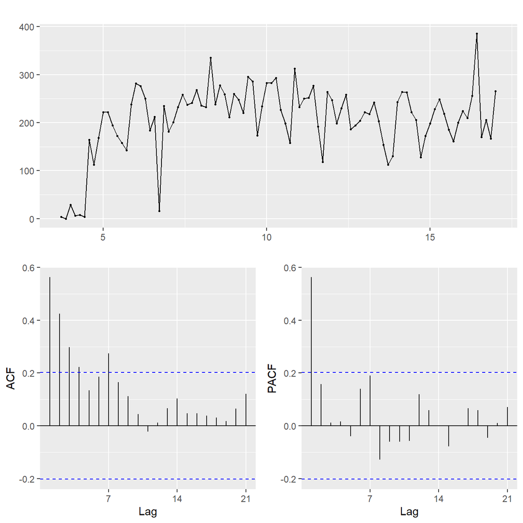

*Figure 1-a:* *This figure provides the general time series plot for store 20974.* *Figure 1-b:* *This figure provides the seasonal trend for store 20974.* *Figure 1-c:* *This figure provides the ACF and PACF plot for store 20974.*

From the figure above, we can see that the time series plot needs to be test more before developing a time series model, and the second plot indicates seasonal trends for the quantity.  
### Exploratory Data Analysis (EDA) for store 46673

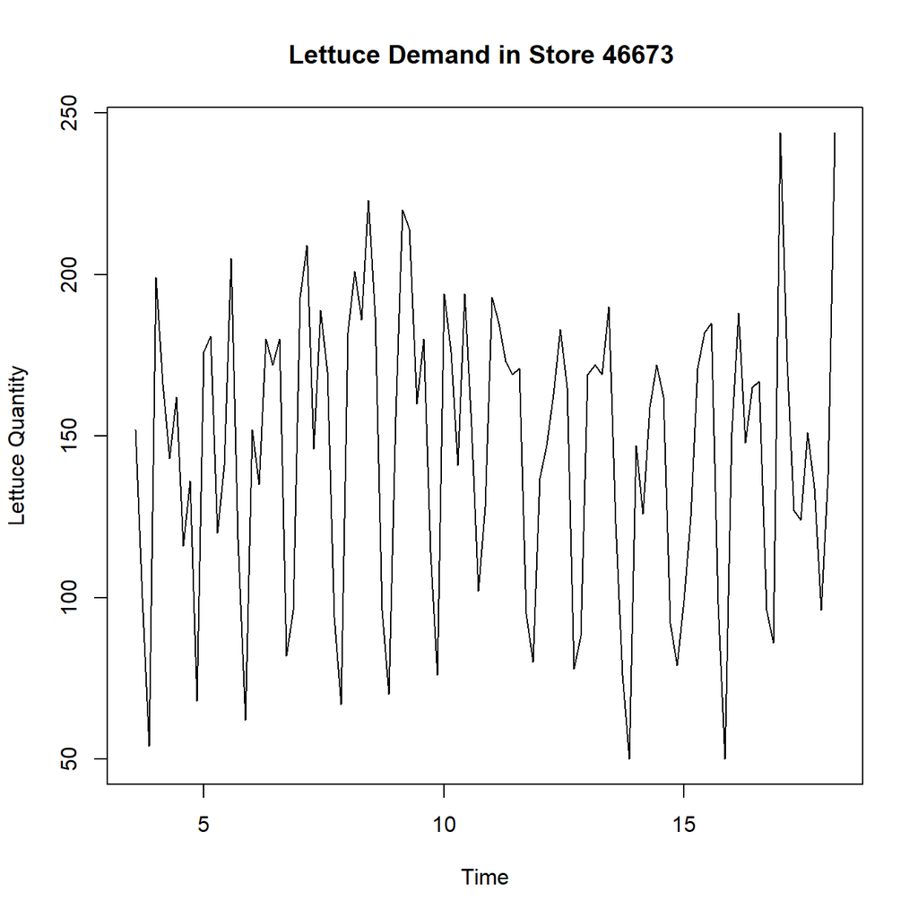

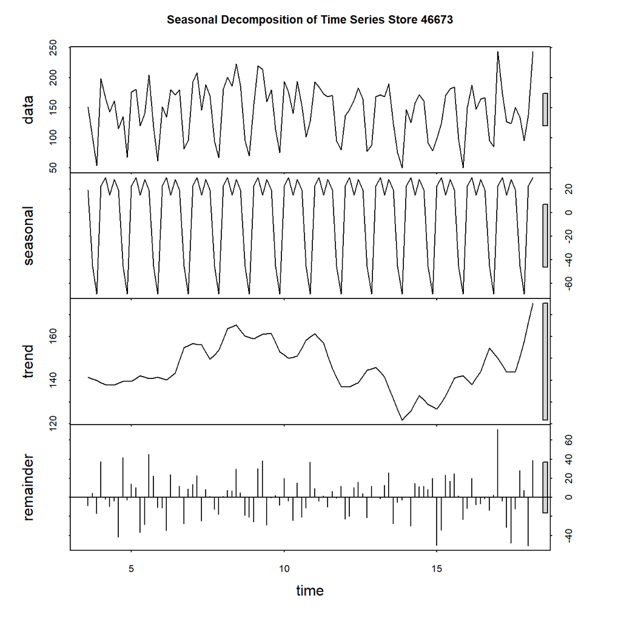

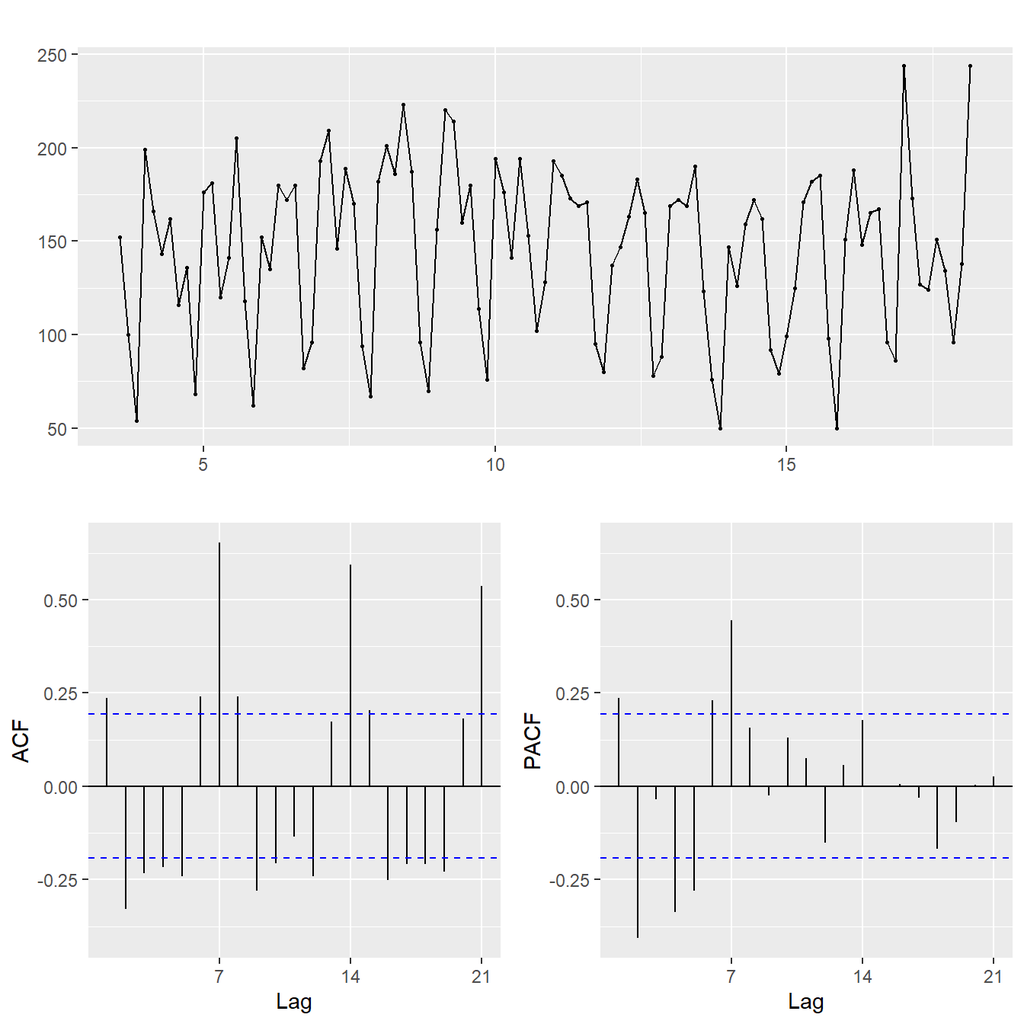

*Figure 1-a:* *This figure provides the general time series plot for store 46673.* *Figure 1-b:* *This figure provides the seasonal trend for store 46673.* *Figure 1-c:* *This figure provides the ACF and PACF plot for store 46673.*

From the figure above, we can see that the time series plot satisfied the assumptions for time series, and the second plot indicates seasonal trends for the quantity.

### Exploratory Data Analysis (EDA) for store 12631

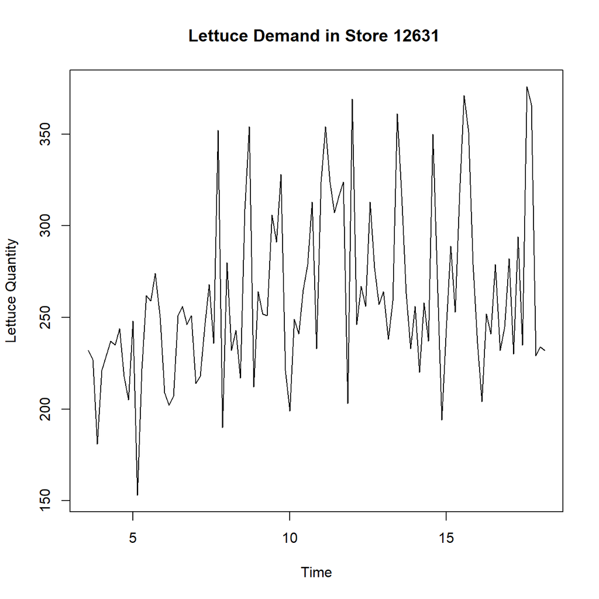

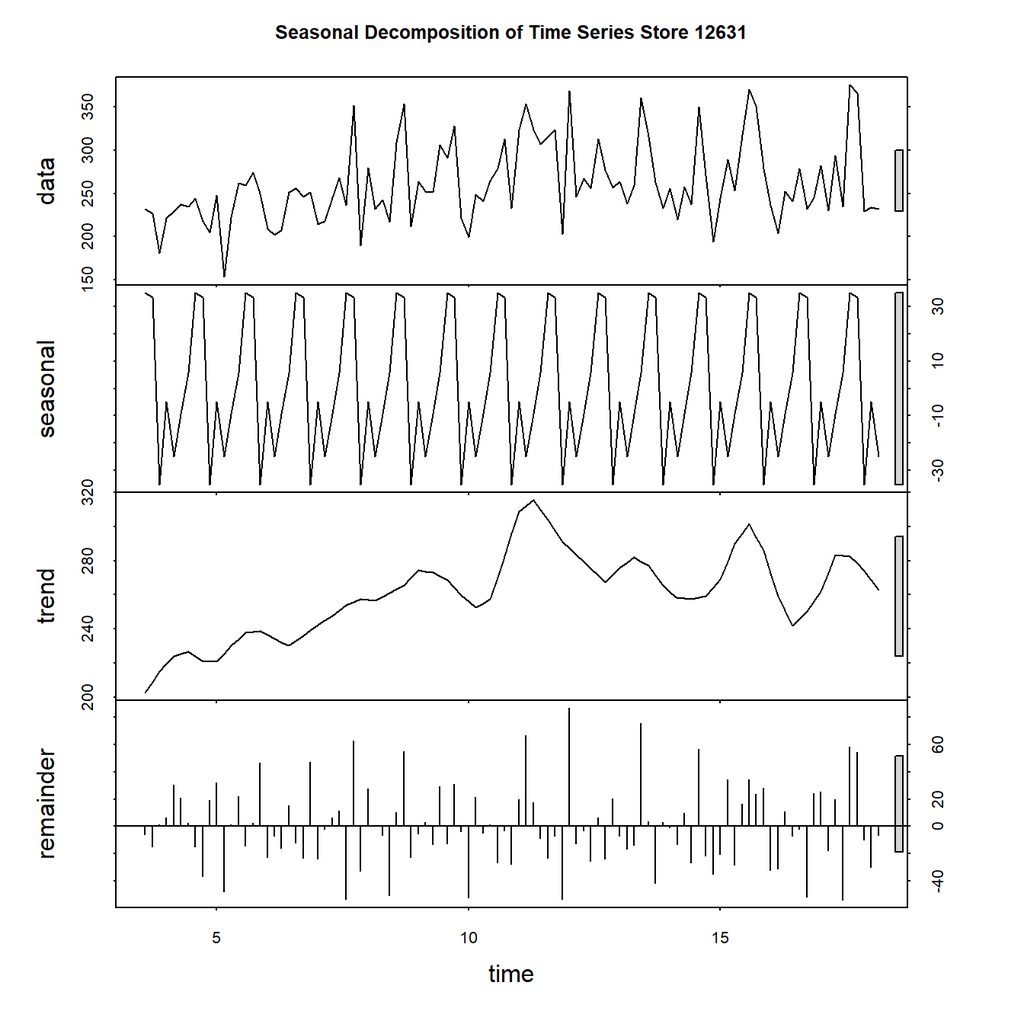

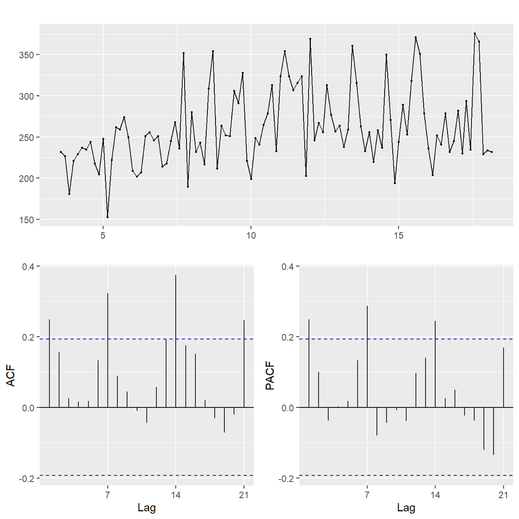

*Figure 1-a:* *This figure provides the general time series plot for store 12631.* *Figure 1-b:* *This figure provides the seasonal trend for store 12631.* *Figure 1-c:* *This figure provides the ACF and PACF plot for store 12631.*

From the figure above, we can see that the time series plot satisfied the assumptions for time series, and the second plot indicates seasonal trends for the quantity.

# Statistical Analysis

## Statistical Analysis for store 4904

To begin with, splitting the dataset into training set and testing set is a must. By selecting the 8.5:1.5 ratio of splitting the original dataset, we can fit the model and test to see the accuracy for further prediction.

```r
train_4904 <- window(ts_4904, end = c(05,78), frequency = 7)
test_4904 <- window(ts_4904, start = c(05,79))
```

### Holt-Winters Method

```r
## Initial Holt-Winters with exponential smoothing
HW_4904 <- HoltWinters(ts_4904, beta = FALSE)
HW_4904
```

```
## Holt-Winters exponential smoothing without trend and with additive seasonal component.
##
## Call:
## HoltWinters(x = ts_4904, beta = FALSE)
##
## Smoothing parameters:
##  alpha: 0.1363722
##  beta : FALSE
##  gamma: 0.222849
##
## Coefficients:
##          [,1]
## a  303.648966
## s1  48.430608
## s2  26.845328
## s3  -6.692316
## s4 -83.667807
## s5 -79.104192
## s6  42.802888
## s7  26.725617
```

```r
## Initial ETS model with automatic fitting
ETS_4904 <- ets(ts_4904, model = 'ZZZ')
ETS_4904
```

```
## ETS(A,N,A)
##
## Call:
##  ets(y = ts_4904, model = "ZZZ")
##
##   Smoothing parameters:
##     alpha = 0.1774
##     gamma = 1e-04
##
##   Initial states:
##     l = 326.7586
##     s = 6.7708 45.7372 57.1993 34.777 34.4967 -89.1465
##            -89.8345
##
##   sigma:  44.3439
##
##      AIC     AICc      BIC
## 1163.638 1166.257 1189.177
```

The Alpha value determines the weight of past data values taking into account, and Gamma determines the weight of the recent the seasonal component.

From the result above, we can see that automatic model select A,N,A model as the best model for this data. We are going to apply the model onto the training and testing set to do the forecasting.

#### Forecasting on Training Set

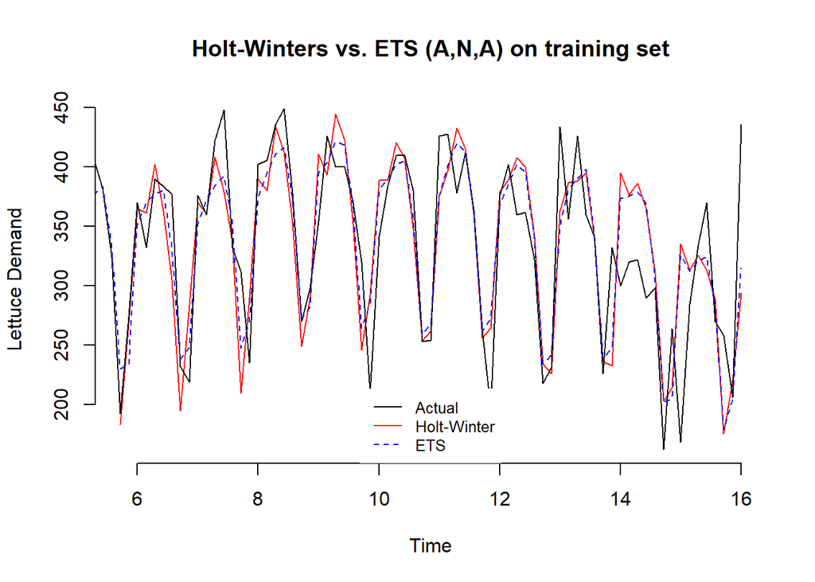

```r
#Holt-Winters
train_HW_4904 <- HoltWinters(train_4904, beta = FALSE)
forecast_HW_4904  <- forecast(train_HW_4904, h = 14)

train_ets_4904 <- ets(train_4904, model = 'ZZZ')
forecast_ets_4904  <- forecast(train_ets_4904, h = 14)

plot(train_HW_4904, main="Holt-Winters vs. ETS (A,N,A) on training set",
     xlab="Time",
     ylab="Lettuce Demand", lty = 1, col = "black", frame.plot = FALSE)
lines(fitted(train_ets_4904), col = "Blue", lty = 2)
legend("bottom", legend=c("Actual","Holt-Winter", "ETS"), col=c("black", "red", "blue"), box.lty=0, lty=c(1,1,2), cex=0.8)
```

*Figure 2.1:* *This figure provides the fitted lines for holt-winter and ETS on store 4904.*

```r
## Accuracy Comparison
acc_ets_HW_4904 <- rbind(forecast::accuracy(forecast_HW_4904,
                                       test_4904),
                        forecast::accuracy(forecast_ets_4904,
                                 test_4904))

acc_ets_HW_4904_df <- data.frame(acc_ets_HW_4904,
                                row.names = c('HW_on_Train', 'HW_on_Test',
                                              'ETS_on_Train', 'ETS_on_Test'))

acc_ets_HW_4904_df %>%  kable(caption = "Accuracy: Holt-Winter vs. ETS",
                                  align = 'c') %>%
  kable_styling() %>%
  pack_rows("Holt-Winters", 1, 2) %>%
  pack_rows("ETS", 3, 4)
```

Accuracy: Holt-Winter vs. ETS

|  | ME | RMSE | MAE | MPE | MAPE | MASE | ACF1 | Theil.s.U |
| --- | --- | --- | --- | --- | --- | --- | --- | --- |
| **Holt-Winters** |  |  |  |  |  |  |  |  |
| HW_on_Train | -0.8356687 | 49.30983 | 36.06982 | -2.114120 | 12.127268 | 0.7728492 | -0.0885613 | NA |
| HW_on_Test | -3.9892374 | 35.46977 | 27.82628 | -2.226168 | 9.079451 | 0.5962191 | 0.0552131 | 0.4168006 |
| **ETS** |  |  |  |  |  |  |  |  |
| ETS_on_Train | -1.4623658 | 43.48610 | 32.68398 | -2.668021 | 11.261343 | 0.7003026 | -0.0709327 | NA |
| ETS_on_Test | -6.0014162 | 38.56627 | 29.02105 | -2.631746 | 9.452465 | 0.6218188 | 0.0875696 | 0.4441763 |

*Table 2.1:* *This table provides the comparison information for store 4904.*

#### Final ETS Model

```r
final_ets_4904 <- forecast(ETS_4904, h = 14)
final_ets_4904_1 <- as.data.frame(forecast(ETS_4904, h = 14))
final_ets_4904_df <- data.frame(final_ets_4904_1$`Point Forecast`,
                     row.names = c('16/06/15', '17/06/15',
                                   '18/06/15', '19/06/15',
                                   '20/06/15', '21/06/15',
                                   '22/06/15','23/06/15',
                                   '24/06/15', '25/06/15',
                                   '26/06/15', '27/06/15',
                                   '28/06/15', '29/06/15'))
final_ets_4904_df %>%
  kable(caption = "14 Day ETS Forecast for Store 4904", align = 'c', col.names = 'Lettuce Demand') %>%
  kable_styling(full_width = F)
```

14 Day ETS Forecast for Store 4904

|  | Lettuce Demand |
| --- | --- |
| 16/06/15 | 359.2945 |
| 17/06/15 | 347.8354 |
| 18/06/15 | 308.8660 |
| 19/06/15 | 212.2648 |
| 20/06/15 | 212.9511 |
| 21/06/15 | 336.5967 |
| 22/06/15 | 336.8785 |
| 23/06/15 | 359.2945 |
| 24/06/15 | 347.8354 |
| 25/06/15 | 308.8660 |
| 26/06/15 | 212.2648 |
| 27/06/15 | 212.9511 |
| 28/06/15 | 336.5967 |
| 29/06/15 | 336.8785 |

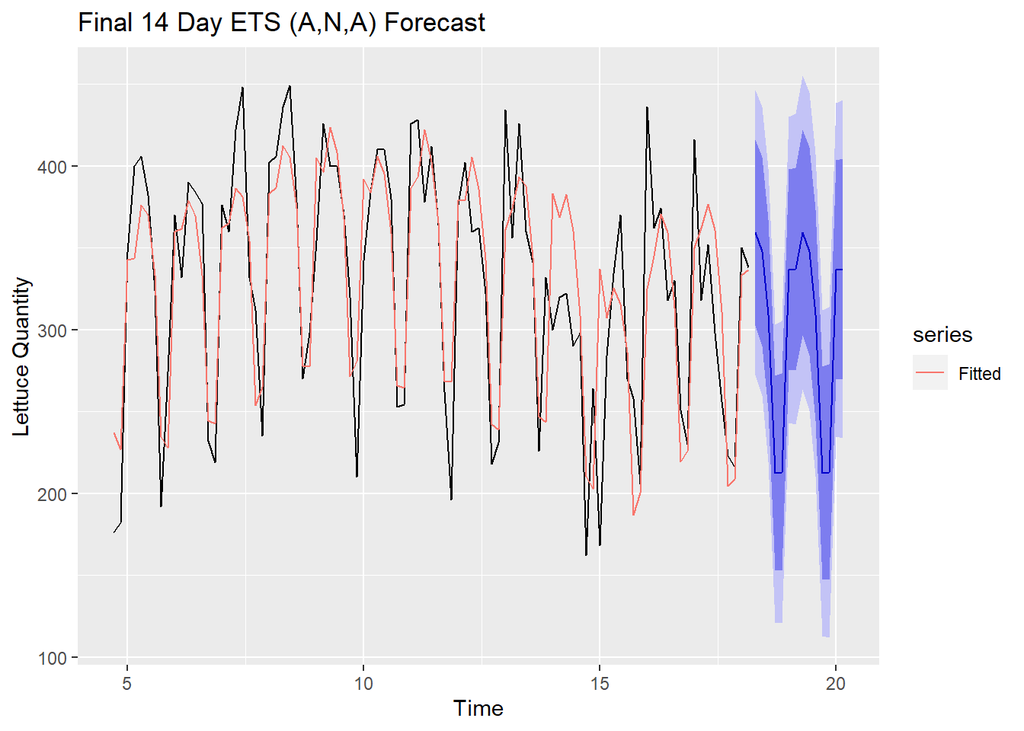

```r
autoplot(final_ets_4904,
         main = 'Final 14 Day ETS (A,N,A) Forecast',
         ylab = 'Lettuce Quantity',
         xlab = 'Time') +
  autolayer(fitted(final_ets_4904),
            series = 'Fitted', na.rm=TRUE)
```

*Table 2.2:* *This table provides the ETS forecasting fitted value for store 4904.*  
*Figure 2.2:* *This figure provides the forecasting plot for store 4904.*

### ARIMA Forecast Models

I then develop the ARIMA model for store 4904 to forecast the demand of lettuce. The ARIMA model will then be compared with the final ETS model above to determine which is the most accuracy model and to do the further forecasting based on the accuracy of the model.

```r
## Testing stationary
adf.test(ts_4904)
```

```
##
##  Augmented Dickey-Fuller Test
##
## data:  ts_4904
## Dickey-Fuller = -5.8332, Lag order = 4, p-value = 0.01
## alternative hypothesis: stationary
```

```r
kpss.test(ts_4904, null = 'Trend')
```

```
##
##  KPSS Test for Trend Stationarity
##
## data:  ts_4904
## KPSS Trend = 0.12855, Truncation lag parameter = 3, p-value = 0.08232
```

```r
pp.test(ts_4904)
```

```
##
##  Phillips-Perron Unit Root Test
##
## data:  ts_4904
## Dickey-Fuller Z(alpha) = -53.838, Truncation lag parameter = 3, p-value
## = 0.01
## alternative hypothesis: stationary
```

```r
ndiffs(ts_4904)
```

```
## [1] 0
```

```r
nsdiffs(ts_4904)
```

```
## [1] 1
```

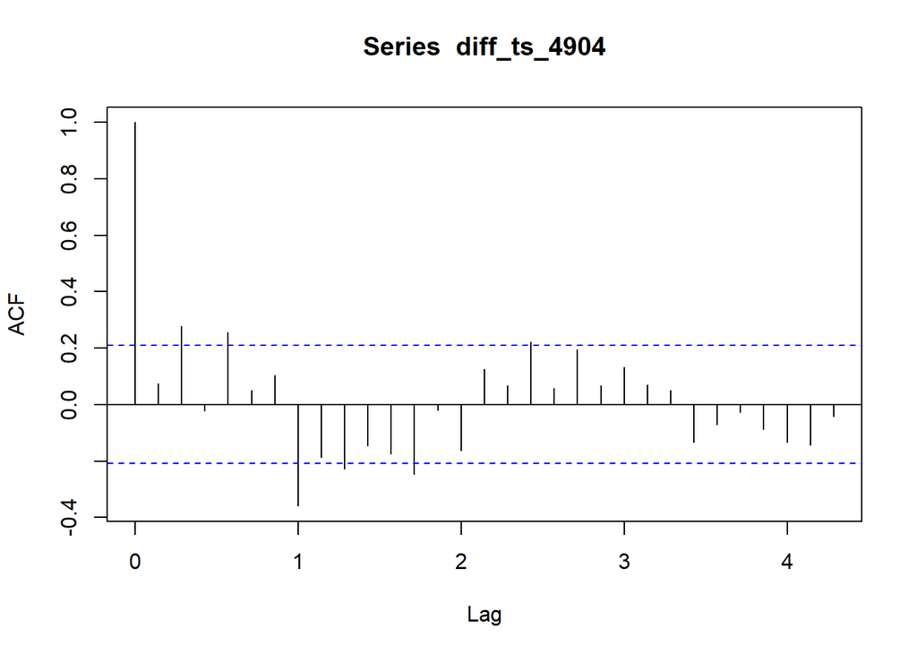

```r
diff_ts_4904 <- diff(ts_4904, lag = 7, differences = 1)
acf(diff_ts_4904, lag.max = 30)
```

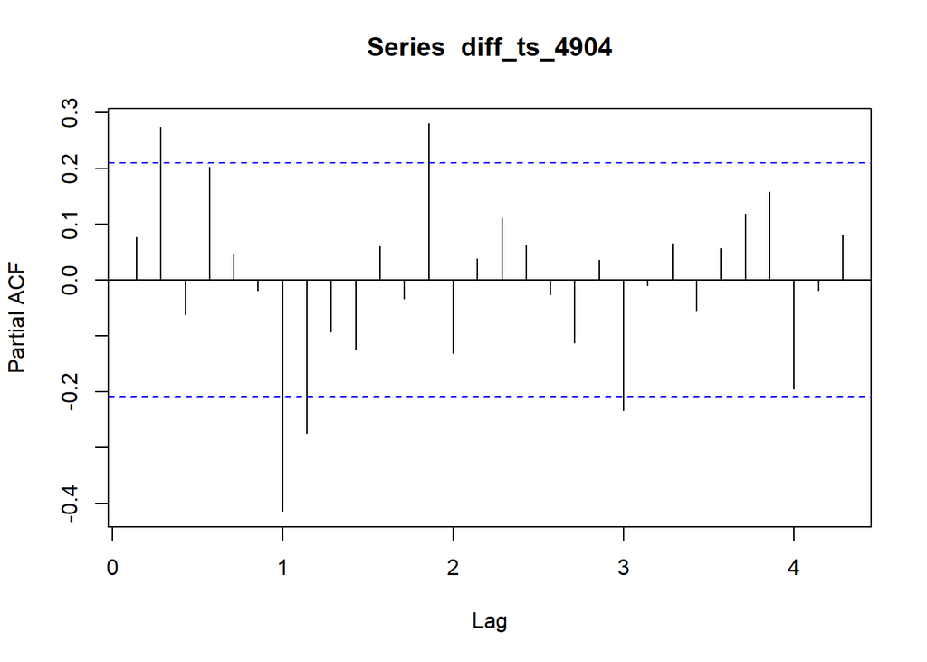

```r
pacf(diff_ts_4904, lag.max = 30)
```

*Figure 2.3:* *This figure provides the ACF and PACF information for store 4904.*

```r
auto.arima(ts_4904, d=0, D=1, trace = TRUE, ic = 'aic', approximation = FALSE)
```

```
##
##  ARIMA(2,0,2)(1,1,1)[7] with drift         : Inf
##  ARIMA(0,0,0)(0,1,0)[7] with drift         : 970.1652
##  ARIMA(1,0,0)(1,1,0)[7] with drift         : 961.4475
##  ARIMA(0,0,1)(0,1,1)[7] with drift         : 945.4019
##  ARIMA(0,0,0)(0,1,0)[7]                    : 968.2772
##  ARIMA(0,0,1)(0,1,0)[7] with drift         : 971.8417
##  ARIMA(0,0,1)(1,1,1)[7] with drift         : Inf
##  ARIMA(0,0,1)(0,1,2)[7] with drift         : Inf
##  ARIMA(0,0,1)(1,1,0)[7] with drift         : 961.5595
##  ARIMA(0,0,1)(1,1,2)[7] with drift         : Inf
##  ARIMA(0,0,0)(0,1,1)[7] with drift         : 944.9699
##  ARIMA(0,0,0)(1,1,1)[7] with drift         : Inf
##  ARIMA(0,0,0)(0,1,2)[7] with drift         : Inf
##  ARIMA(0,0,0)(1,1,0)[7] with drift         : 959.7571
##  ARIMA(0,0,0)(1,1,2)[7] with drift         : 945.2722
##  ARIMA(1,0,0)(0,1,1)[7] with drift         : 944.3704
##  ARIMA(1,0,0)(0,1,0)[7] with drift         : 971.6632
##  ARIMA(1,0,0)(1,1,1)[7] with drift         : Inf
##  ARIMA(1,0,0)(0,1,2)[7] with drift         : Inf
##  ARIMA(1,0,0)(1,1,2)[7] with drift         : Inf
##  ARIMA(2,0,0)(0,1,1)[7] with drift         : 938.7983
##  ARIMA(2,0,0)(0,1,0)[7] with drift         : 966.6447
##  ARIMA(2,0,0)(1,1,1)[7] with drift         : Inf
##  ARIMA(2,0,0)(0,1,2)[7] with drift         : Inf
##  ARIMA(2,0,0)(1,1,0)[7] with drift         : 955.9003
##  ARIMA(2,0,0)(1,1,2)[7] with drift         : Inf
##  ARIMA(3,0,0)(0,1,1)[7] with drift         : 940.7616
##  ARIMA(2,0,1)(0,1,1)[7] with drift         : 939.6613
##  ARIMA(1,0,1)(0,1,1)[7] with drift         : 939.1212
##  ARIMA(3,0,1)(0,1,1)[7] with drift         : 942.683
##  ARIMA(2,0,0)(0,1,1)[7]                    : 938.3156
##  ARIMA(2,0,0)(0,1,0)[7]                    : 964.6823
##  ARIMA(2,0,0)(1,1,1)[7]                    : 938.7159
##  ARIMA(2,0,0)(0,1,2)[7]                    : 938.4265
##  ARIMA(2,0,0)(1,1,0)[7]                    : 953.975
##  ARIMA(2,0,0)(1,1,2)[7]                    : 939.4047
##  ARIMA(1,0,0)(0,1,1)[7]                    : 945.904
##  ARIMA(3,0,0)(0,1,1)[7]                    : 940.0882
##  ARIMA(2,0,1)(0,1,1)[7]                    : 938.1194
##  ARIMA(2,0,1)(0,1,0)[7]                    : 964.894
##  ARIMA(2,0,1)(1,1,1)[7]                    : 939.6369
##  ARIMA(2,0,1)(0,1,2)[7]                    : 939.4754
##  ARIMA(2,0,1)(1,1,0)[7]                    : 955.7647
##  ARIMA(2,0,1)(1,1,2)[7]                    : 939.9381
##  ARIMA(1,0,1)(0,1,1)[7]                    : 937.5026
##  ARIMA(1,0,1)(0,1,0)[7]                    : 968.9363
##  ARIMA(1,0,1)(1,1,1)[7]                    : Inf
##  ARIMA(1,0,1)(0,1,2)[7]                    : Inf
##  ARIMA(1,0,1)(1,1,0)[7]                    : 957.8611
##  ARIMA(1,0,1)(1,1,2)[7]                    : Inf
##  ARIMA(0,0,1)(0,1,1)[7]                    : 946.9524
##  ARIMA(1,0,2)(0,1,1)[7]                    : 938.4221
##  ARIMA(0,0,0)(0,1,1)[7]                    : 946.3181
##  ARIMA(0,0,2)(0,1,1)[7]                    : 941.7574
##  ARIMA(2,0,2)(0,1,1)[7]                    : 938.7436
##
##  Best model: ARIMA(1,0,1)(0,1,1)[7]
```

```
## Series: ts_4904
## ARIMA(1,0,1)(0,1,1)[7]
##
## Coefficients:
##          ar1      ma1     sma1
##       0.9442  -0.7642  -0.8873
## s.e.  0.0677   0.1092   0.1537
##
## sigma^2 estimated as 2101:  log likelihood=-464.75
## AIC=937.5   AICc=937.98   BIC=947.41
```

#### ARIMA Functions Selected

The best model is determined to be ARIMA(1,0,1)(0,1,1)[7], which indicates that we can put ARIMA(p,0,q)(0,1,1) with period 7 into the pool.

```r
arima1_4904 <- Arima(ts_4904, order = c(1, 0 ,0), seasonal = list(order = c(0, 1, 1), period = 7))
arima2_4904 <- Arima(ts_4904, order = c(1, 0 ,1), seasonal = list(order = c(0, 1, 1), period = 7))
arima3_4904 <- Arima(ts_4904, order = c(1, 0 ,2), seasonal = list(order = c(0, 1, 1), period = 7))
arima4_4904 <- Arima(ts_4904, order = c(0, 0 ,1), seasonal = list(order = c(0, 1, 1), period = 7))
arima5_4904 <- Arima(ts_4904, order = c(0, 0 ,2), seasonal = list(order = c(0, 1, 1), period = 7))
```

The forecast function is used on each ARIMA model and used with a 14 period forecast.

```r
# 14 day ARIMA forecast
forecast_arima1_4904 <- forecast(arima1_4904, h = 14)
forecast_arima2_4904 <- forecast(arima2_4904, h = 14)
forecast_arima3_4904 <- forecast(arima3_4904, h = 14)
forecast_arima4_4904 <- forecast(arima4_4904, h = 14)
forecast_arima5_4904 <- forecast(arima5_4904, h = 14)
```

```r
accuracy_arima_4904 <- rbind(forecast::accuracy(forecast_arima1_4904), forecast::accuracy(forecast_arima2_4904), forecast::accuracy(forecast_arima3_4904),
           forecast::accuracy(forecast_arima4_4904), forecast::accuracy(forecast_arima5_4904))

accuracy_arima_4904_k <- data.frame(accuracy_arima_4904,
                                     row.names = c('ARIMA(1,0,0)(0,1,1)',
                                                   'ARIMA(1,0,1)(0,1,1)',
                                                   'ARIMA(1,0,2)(0,1,1)',
                                                   'ARIMA(0,0,1)(0,1,1)',
                                                   'ARIMA(0,0,2)(0,1,1)'))
accuracy_arima_4904_k %>%  kable(caption = "Accuracy of ARIMA Model", align = 'c') %>%  kable_styling(full_width = F)
```

Accuracy of ARIMA Model

|  | ME | RMSE | MAE | MPE | MAPE | MASE | ACF1 |
| --- | --- | --- | --- | --- | --- | --- | --- |
| ARIMA(1,0,0)(0,1,1) | -3.5168678 | 47.06256 | 33.81302 | -2.839186 | 11.53530 | 0.7483768 | -0.0622338 |
| ARIMA(1,0,1)(0,1,1) | -0.9749886 | 43.35704 | 30.87064 | -1.475590 | 10.31033 | 0.6832535 | -0.0758337 |
| ARIMA(1,0,2)(0,1,1) | -1.1233676 | 43.60544 | 31.72584 | -1.476476 | 10.50023 | 0.7021815 | -0.0070168 |
| ARIMA(0,0,1)(0,1,1) | -3.6250193 | 47.57062 | 34.32185 | -2.911506 | 11.69128 | 0.7596384 | 0.0287719 |
| ARIMA(0,0,2)(0,1,1) | -2.9941237 | 45.31566 | 33.32230 | -2.498795 | 11.22827 | 0.7375157 | 0.0104968 |

*Table 2.3:* *This table provides the model pool information for store 4904.*

```r
#Training arima
training_arima2_4904 <- arima(train_4904,
                                    order = c(1, 0 ,1),
                                    seasonal = list(order = c(0, 1, 1),
                                                    period = 7))
training_arima3_4904 <- arima(train_4904,
                                    order = c(1, 0 ,2),
                                    seasonal = list(order = c(0, 1, 1),
                                                    period = 7))
training_arima5_4904 <- arima(train_4904,
                                    order = c(0, 0 ,2),
                                    seasonal = list(order = c(0, 1, 1),
                                                    period = 7))

## Forecast using the training set
forecast_arima2_4904 <- forecast(training_arima2_4904, h = 19)
forecast_arima3_4904 <- forecast(training_arima3_4904, h = 19)
forecast_arima5_4904 <- forecast(training_arima5_4904, h = 19)
```

```r
accuracy_final_arima_4904 <- rbind(accuracy(forecast_arima2_4904,
                                            test_4904),
                              accuracy(forecast_arima3_4904,
                                       test_4904),
                              accuracy(forecast_arima5_4904,
                                       test_4904))

accuracy_final_arima_4904_k <- data.frame(accuracy_final_arima_4904,
                                          row.names = c('Train_2', 'Test_2',
                                                        'Train_3', 'Test_3',
                                                        'Train_5', 'Test_5'))

accuracy_final_arima_4904_k %>%  kable(caption = "Accuracy of ARIMA Models", align = 'c') %>%  kable_styling(full_width = F) %>%
  pack_rows("ARIMA(1,0,1)(0,1,1)", 1, 2) %>%
  pack_rows("ARIMA(1,0,2)(0,1,1)", 3, 4) %>%
  pack_rows("ARIMA(0,0,2)(0,1,1))", 5, 6)
```

Accuracy of ARIMA Models

|  | ME | RMSE | MAE | MPE | MAPE | MASE | ACF1 | Theil.s.U |
| --- | --- | --- | --- | --- | --- | --- | --- | --- |
| **ARIMA(1,0,1)(0,1,1)** |  |  |  |  |  |  |  |  |
| Train_2 | 0.5749261 | 42.51866 | 30.10576 | -1.0405877 | 10.105801 | 0.6450604 | -0.1040571 | NA |
| Test_2 | -19.3701655 | 40.75886 | 30.13506 | -7.0069367 | 9.981522 | 0.6456880 | 0.1616699 | 0.4564994 |
| **ARIMA(1,0,2)(0,1,1)** |  |  |  |  |  |  |  |  |
| Train_3 | 0.9452312 | 41.89626 | 30.13665 | -0.7407474 | 9.955581 | 0.6457223 | 0.0020268 | NA |
| Test_3 | -27.6952023 | 45.54191 | 36.16522 | -9.8281087 | 12.028670 | 0.7748931 | 0.1534660 | 0.4963796 |
| **ARIMA(0,0,2)(0,1,1))** |  |  |  |  |  |  |  |  |
| Train_5 | -1.4615504 | 46.49630 | 33.58261 | -2.1440730 | 11.386090 | 0.7195570 | 0.0229309 | NA |
| Test_5 | -21.3533456 | 40.18131 | 31.77106 | -7.7327104 | 10.554486 | 0.6807417 | 0.1213440 | 0.4562706 |

*Table 2.4:* *This table provides the model comparison information for store 4904.*

#### Final ARIMA Model

```r
## Best model plotted
best_arima_4904 <- arima(ts_4904,
                               order = c(1, 0 ,2),
                               seasonal = list(order = c(0, 1, 1),
                                               period = 7))
forecast_best_arima_4904 <- forecast(best_arima_4904, h = 14)
forecast_best_arima_4904_1 <- as.data.frame(forecast_best_arima_4904)

forecast_best_arima_4904_df <- data.frame(forecast_best_arima_4904_1$`Point Forecast`,
                                               row.names = c('16/06/15', '17/06/15', '18/06/15',
                                                             '19/06/15', '20/06/15', '21/06/15',
                                                             '22/06/15', '23/06/15', '24/06/15',
                                                             '25/06/15', '26/06/15', '27/06/15',
                                                             '28/06/15', '29/06/15'))
forecast_best_arima_4904_df %>%  kable(caption = "Final 14 Day ARIMA Forecast", align = 'c',  col.names = 'Lettuce Demand') %>%  kable_styling(full_width = F)
```

Final 14 Day ARIMA Forecast

|  | Lettuce Demand |
| --- | --- |
| 16/06/15 | 355.3617 |
| 17/06/15 | 338.1733 |
| 18/06/15 | 303.3082 |
| 19/06/15 | 224.3202 |
| 20/06/15 | 226.8582 |
| 21/06/15 | 351.9907 |
| 22/06/15 | 341.4871 |
| 23/06/15 | 361.4916 |
| 24/06/15 | 343.0236 |
| 25/06/15 | 307.6596 |
| 26/06/15 | 228.2242 |
| 27/06/15 | 230.3607 |
| 28/06/15 | 355.1331 |
| 29/06/15 | 344.3064 |

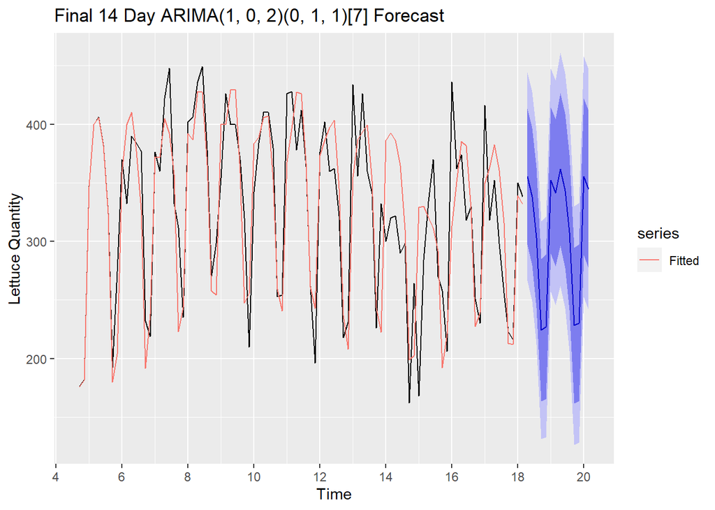

```r
autoplot(forecast_best_arima_4904,
         main = 'Final 14 Day ARIMA(1, 0, 2)(0, 1, 1)[7] Forecast',
         ylab = 'Lettuce Quantity', xlab = 'Time') +
  autolayer(fitted(forecast_best_arima_4904), series = 'Fitted', na.rm=TRUE) +
  scale_x_continuous(breaks = seq(0, 22, by = 2))
```

*Table 2.5:* *This table provides the final prediction value of time series for store 4904.* *Figure 2.4:* *This table provides the final prediction plot for store 4904.*

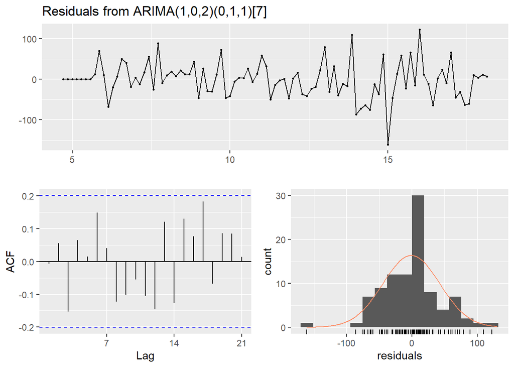

```
##
##  Ljung-Box test
##
## data:  Residuals from ARIMA(1,0,2)(0,1,1)[7]
## Q* = 15.741, df = 10, p-value = 0.1073
##
## Model df: 4.   Total lags used: 14
```

```r
checkresiduals(forecast_best_arima_4904)
```

*Figure 2.5:* *This figure provides the residual and test for store 4904.*

The four tests above indicate that the ARIMA(1, 0, 2)(0, 1, 1)[7] model is a sufficient predictive model.

### Final Forecast for Resturant 4904: ETS(A,N,A) vs. ARIMA(1, 0, 2)(0, 1, 1)[7]

```r
## Checking which model based on RMSE
accuracy_final_model_all_4904 <- rbind(forecast::accuracy(forecast_ets_4904, test_4904),
                                       forecast::accuracy(forecast_arima3_4904, test_4904))
accuracy_final_model_all_4904_df <- data.frame(accuracy_final_model_all_4904,
                                               row.names = c('Train_ets', 'Test_ets', 'Train_ts', 'Test_ts'))

accuracy_final_model_all_4904_df %>%  kable(caption = "Accuracy of Best ETS and ARIMA", align = 'c') %>%
  kable_styling(full_width = F) %>%
  pack_rows("ETS(A,N,A)", 1, 2) %>%
  pack_rows("ARIMA(1,0,2)(0,1,1)", 3, 4)
```

Accuracy of Best ETS and ARIMA

|  | ME | RMSE | MAE | MPE | MAPE | MASE | ACF1 | Theil.s.U |
| --- | --- | --- | --- | --- | --- | --- | --- | --- |
| **ETS(A,N,A)** |  |  |  |  |  |  |  |  |
| Train_ets | -1.4623658 | 43.48610 | 32.68398 | -2.6680210 | 11.261343 | 0.7003026 | -0.0709327 | NA |
| Test_ets | -6.0014162 | 38.56627 | 29.02105 | -2.6317462 | 9.452465 | 0.6218188 | 0.0875696 | 0.4441763 |
| **ARIMA(1,0,2)(0,1,1)** |  |  |  |  |  |  |  |  |
| Train_ts | 0.9452312 | 41.89626 | 30.13665 | -0.7407474 | 9.955581 | 0.6457223 | 0.0020268 | NA |
| Test_ts | -27.6952023 | 45.54191 | 36.16522 | -9.8281087 | 12.028670 | 0.7748931 | 0.1534660 | 0.4963796 |

*Table 2.6:* *This Table provides the methods comparison information for store 4904.*

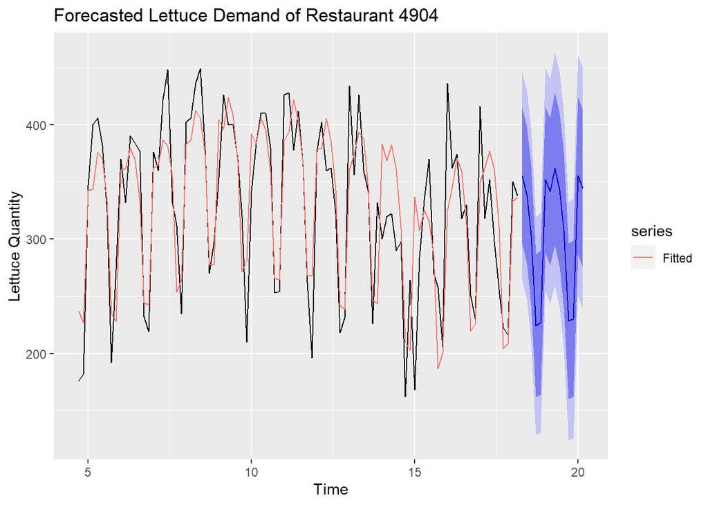

```r
# Best model
final_4904 <- forecast(arima3_4904, h = 14)

autoplot(final_4904,
         main = 'Forecasted Lettuce Demand of Restaurant 4904',
         ylab = 'Lettuce Quantity',
         xlab = 'Time') +
  autolayer(fitted(final_ets_4904), series = 'Fitted', na.rm=TRUE)
```

```r
#Write to csv
write.csv(final_4904, 'final_4904.csv')

## Final Forecast (Table)
final_4904_1 <- as.data.frame(forecast(arima3_4904, h = 14))
final_4904_df <- data.frame(final_4904_1$`Point Forecast`,
                                 row.names = c('16/06/15', '17/06/15', '18/06/15', '19/06/15',
                                               '20/06/15', '21/06/15', '22/06/15', '23/06/15',
                                               '24/06/15', '25/06/15', '26/06/15', '27/06/15',
                                               '28/06/15', '29/06/15'))
final_4904_df %>%  kable(caption = "Final 14 Day ARIMA Forecast", align = 'c', col.names = 'Lettuce Demand') %>%  kable_styling(full_width = F)
```

Final 14 Day ARIMA Forecast

|  | Lettuce Demand |
| --- | --- |
| 16/06/15 | 355.3617 |
| 17/06/15 | 338.1733 |
| 18/06/15 | 303.3082 |
| 19/06/15 | 224.3202 |
| 20/06/15 | 226.8582 |
| 21/06/15 | 351.9907 |
| 22/06/15 | 341.4871 |
| 23/06/15 | 361.4916 |
| 24/06/15 | 343.0236 |
| 25/06/15 | 307.6596 |
| 26/06/15 | 228.2242 |
| 27/06/15 | 230.3607 |
| 28/06/15 | 355.1331 |
| 29/06/15 | 344.3064 |

*Figure 2.6:* *This figure provides the final forecasting plot for store 4904.*  
*Table 2.7:* *This table provides the final forecasting value for store 4904.*

## Statistical Analysis for store 20974

To begin with, splitting the dataset into training set and testing set is a must. By selecting the 8.5:1.5 ratio of splitting the original dataset, we can fit the model and test to see the accuracy for further prediction.

```r
train_20974 <- window(ts_20974, end = c(03,85), frequency = 7)
test_20974 <- window(ts_20974, start = c(03,86))
```

### Holt-Winters Method

```r
## Initial Holt-Winters with exponential smoothing
HW_20974 <- HoltWinters(ts_20974, beta = FALSE)
HW_20974
```

```
## Holt-Winters exponential smoothing without trend and with additive seasonal component.
##
## Call:
## HoltWinters(x = ts_20974, beta = FALSE)
##
## Smoothing parameters:
##  alpha: 0.3056737
##  beta : FALSE
##  gamma: 0.3984021
##
## Coefficients:
##          [,1]
## a  209.721979
## s1  45.518637
## s2  67.782061
## s3  82.327311
## s4 -16.762841
## s5 -32.103088
## s6  -9.159774
## s7  48.156004
```

```r
## Initial ETS model with automatic fitting
ETS_20974 <- ets(ts_20974, model = 'ZZZ')
ETS_20974
```

```
## ETS(A,Ad,A)
##
## Call:
##  ets(y = ts_20974, model = "ZZZ")
##
##   Smoothing parameters:
##     alpha = 0.1309
##     beta  = 0.0053
##     gamma = 5e-04
##     phi   = 0.9254
##
##   Initial states:
##     l = -20.3284
##     b = 21.8993
##     s = -16.0598 14.9368 28.8042 12.3617 12.9386 2.8771
##            -55.8587
##
##   sigma:  50.4337
##
##      AIC     AICc      BIC
## 1177.315 1181.865 1210.378
```

We are going to apply the model onto the training and testing set to do the forecasting.

#### Forecasting on Training Set

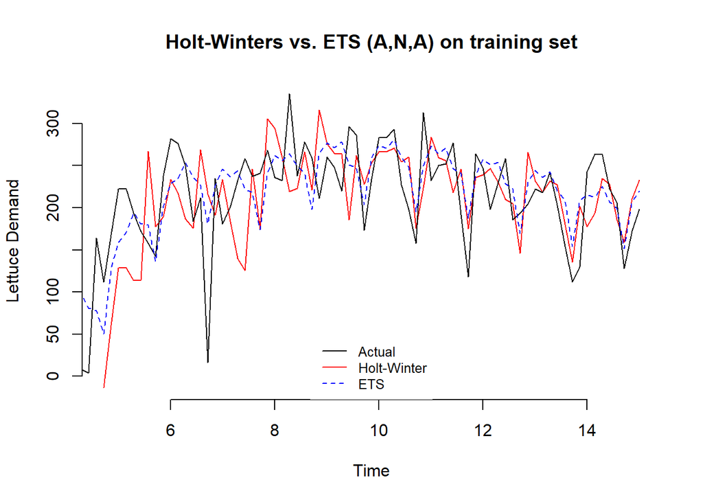

```r
#Holt-Winters
train_HW_20974 <- HoltWinters(train_20974, beta = FALSE)
forecast_HW_20974  <- forecast(train_HW_20974, h = 14)
#ets
train_ets_20974 <- ets(train_20974, model = 'ZZZ')
forecast_ets_20974  <- forecast(train_ets_20974, h = 14)

plot(train_HW_20974, main="Holt-Winters vs. ETS (A,N,A) on training set",
     xlab="Time",
     ylab="Lettuce Demand", lty = 1, col = "black", frame.plot = FALSE)
lines(fitted(train_ets_20974), col = "Blue", lty = 2)
legend("bottom", legend=c("Actual","Holt-Winter", "ETS"), col=c("black", "red", "blue"), box.lty=0, lty=c(1,1,2), cex=0.8)
```

*Figure 3.1:* *This figure provides the fitted lines for holt-winter and ETS on store 20974.*

```r
## Accuracy Comparison
acc_ets_HW_20974 <- rbind(forecast::accuracy(forecast_HW_20974,
                                       test_20974),
                        forecast::accuracy(forecast_ets_20974,
                                 test_20974))

acc_ets_HW_20974_df <- data.frame(acc_ets_HW_20974,
                                row.names = c('HW_on_Train', 'HW_on_Test',
                                              'ETS_on_Train', 'ETS_on_Test'))

acc_ets_HW_20974_df %>%  kable(caption = "Accuracy: Holt-Winter vs. ETS",
                                  align = 'c') %>%
  kable_styling() %>%
  pack_rows("Holt-Winters", 1, 2) %>%
  pack_rows("ETS", 3, 4)
```

Accuracy: Holt-Winter vs. ETS

|  | ME | RMSE | MAE | MPE | MAPE | MASE | ACF1 | Theil.s.U |
| --- | --- | --- | --- | --- | --- | --- | --- | --- |
| **Holt-Winters** |  |  |  |  |  |  |  |  |
| HW_on_Train | 6.299455 | 60.70995 | 48.01069 | -15.063034 | 39.16326 | 0.8384643 | 0.1939396 | NA |
| HW_on_Test | 39.013965 | 62.57655 | 40.75211 | 15.437589 | 16.40232 | 0.7116995 | -0.2349543 | 0.9700623 |
| **ETS** |  |  |  |  |  |  |  |  |
| ETS_on_Train | -6.039023 | 45.29688 | 37.35705 | -Inf | Inf | 0.6524078 | 0.2227129 | NA |
| ETS_on_Test | 28.172924 | 58.65815 | 35.38409 | 9.464418 | 13.72559 | 0.6179518 | -0.2645748 | 0.8704160 |

*Table 3.1:* *This table provides the comparison information for store 20974.*

From the table above, since the ETS model has the lowest RMSE value, we are going to select ETS model.

#### Final ETS Model

```r
final_ets_20974 <- forecast(ETS_20974, h = 14)
final_ets_20974_1 <- as.data.frame(forecast(ETS_20974, h = 14))
final_ets_20974_df <- data.frame(final_ets_20974_1$`Point Forecast`,
                     row.names = c('16/06/15', '17/06/15',
                                   '18/06/15', '19/06/15',
                                   '20/06/15', '21/06/15',
                                   '22/06/15','23/06/15',
                                   '24/06/15', '25/06/15',
                                   '26/06/15', '27/06/15',
                                   '28/06/15', '29/06/15'))
final_ets_20974_df %>%
  kable(caption = "14 Day ETS Forecast for Store 20974", align = 'c', col.names = 'Lettuce Demand') %>%
  kable_styling(full_width = F)
```

14 Day ETS Forecast for Store 20974

|  | Lettuce Demand |
| --- | --- |
| 16/06/15 | 237.9924 |
| 17/06/15 | 254.8547 |
| 18/06/15 | 241.4441 |
| 19/06/15 | 210.8600 |
| 20/06/15 | 171.3848 |
| 21/06/15 | 230.4058 |
| 22/06/15 | 240.8507 |
| 23/06/15 | 240.5104 |
| 24/06/15 | 257.1850 |
| 25/06/15 | 243.6006 |
| 26/06/15 | 212.8556 |
| 27/06/15 | 173.2316 |
| 28/06/15 | 232.1149 |
| 29/06/15 | 242.4323 |

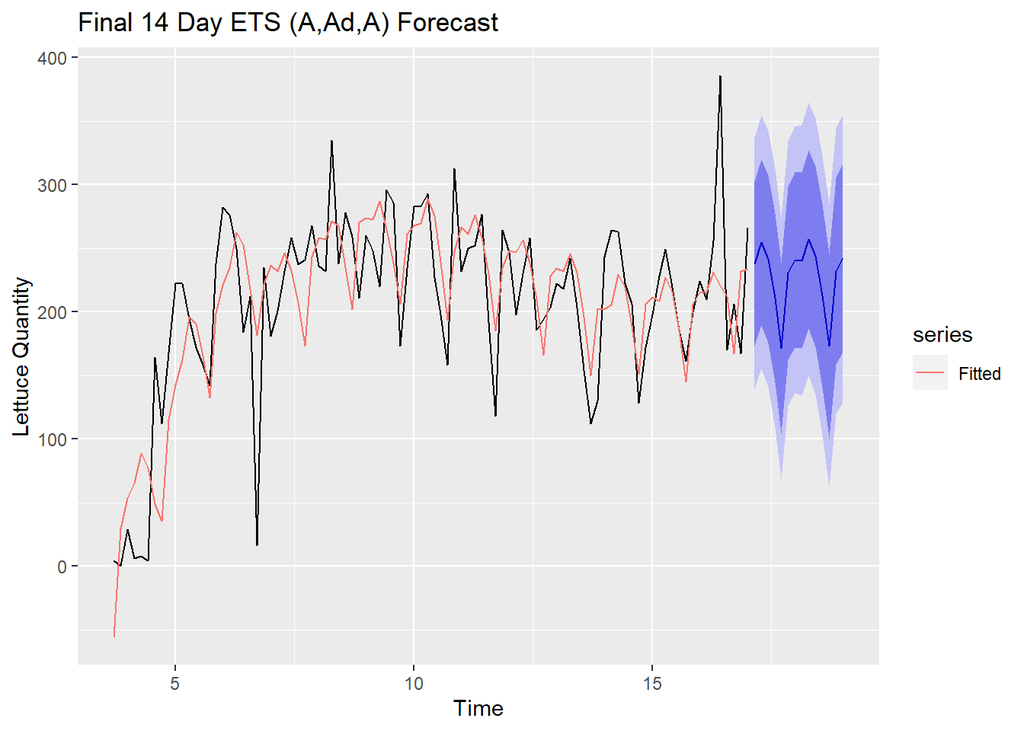

```r
autoplot(final_ets_20974,
         main = 'Final 14 Day ETS (A,Ad,A) Forecast',
         ylab = 'Lettuce Quantity',
         xlab = 'Time') +
  autolayer(fitted(final_ets_20974),
            series = 'Fitted', na.rm=TRUE)
```

*Table 3.2:* *This table provides the ETS forecasting fitted value for store 20974.*  
*Figure 3.2:* *This figure provides the forecasting plot for store 20974.*

### ARIMA Forecast Models

I then develop the ARIMA model for store 20974 to forecast the demand of lettuce. The ARIMA model will then be compared with the final ETS model above to determine which is the most accuracy model and to do the further forecasting based on the accuracy of the model.

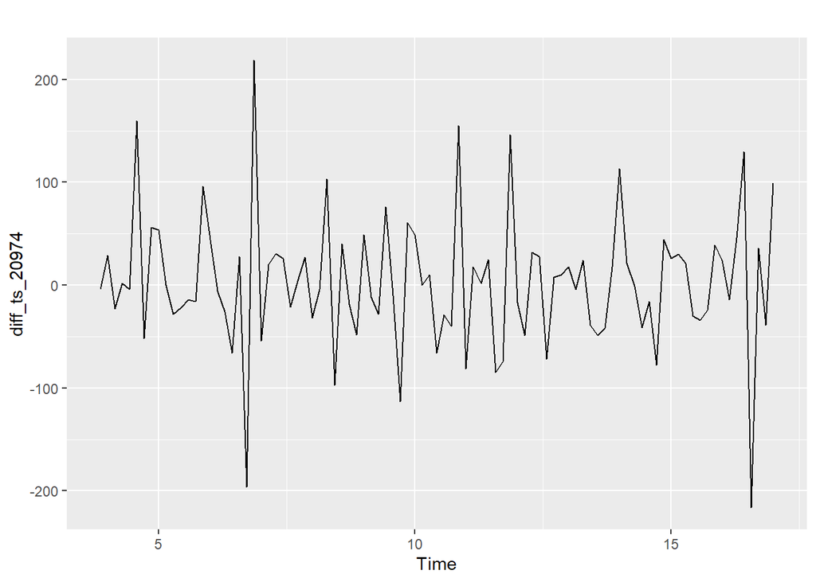

```r
#ts diff
diff_ts_20974 <- diff(ts_20974, differences = 1)
autoplot(diff_ts_20974)
```

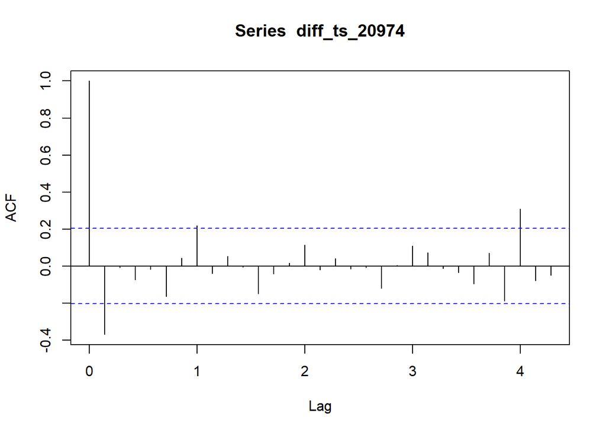

```r
acf(diff_ts_20974, lag.max = 30)
```

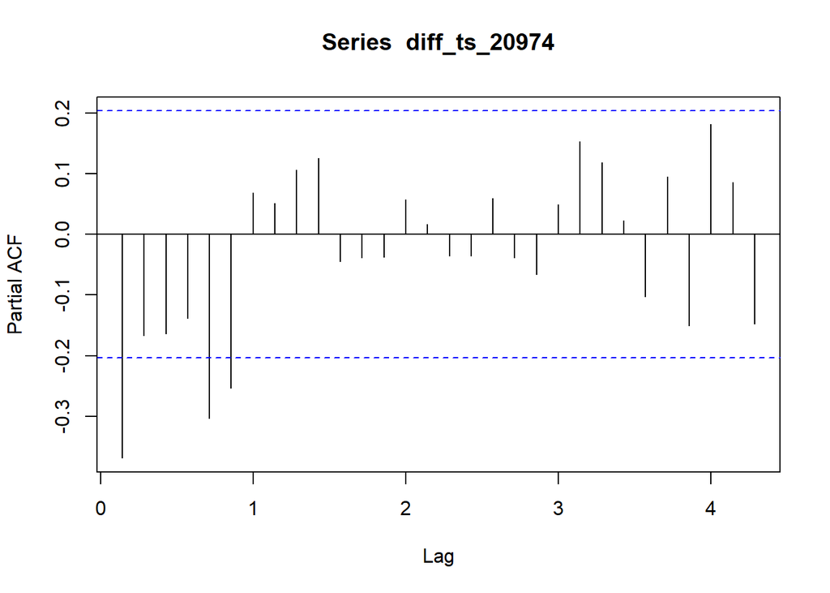

```r
pacf(diff_ts_20974, lag.max = 30)
```

```r
adf.test(diff_ts_20974)
```

```
##
##  Augmented Dickey-Fuller Test
##
## data:  diff_ts_20974
## Dickey-Fuller = -7.6175, Lag order = 4, p-value = 0.01
## alternative hypothesis: stationary
```

```r
kpss.test(diff_ts_20974, null = 'Trend')
```

```
##
##  KPSS Test for Trend Stationarity
##
## data:  diff_ts_20974
## KPSS Trend = 0.041817, Truncation lag parameter = 3, p-value = 0.1
```

```r
pp.test(diff_ts_20974)
```

```
##
##  Phillips-Perron Unit Root Test
##
## data:  diff_ts_20974
## Dickey-Fuller Z(alpha) = -112.32, Truncation lag parameter = 3, p-value
## = 0.01
## alternative hypothesis: stationary
```

```r
ndiffs(diff_ts_20974)
```

```
## [1] 0
```

```r
nsdiffs(diff_ts_20974)
```

```
## [1] 0
```

*Figure 3.3:* *This figure provides the ACF and PACF information for store 20974*

As the p-value for Dickey-Fuller and Phillips-Perron Unit Root Test are smaller than 0.01, and the p-value for KPSS Test is larger than 0.01, the result above indicates stationary for the time series dataset. The ndiffs test return the value 0 and the nsdiffs test return the value of 0 after taking one difference, which indicates seasonal stationary.

```r
auto.arima(ts_20974, d=1, trace = TRUE, ic = 'aic', approximation = FALSE)
```

```
##
##  ARIMA(2,1,2)(1,0,1)[7] with drift         : 1018.605
##  ARIMA(0,1,0)           with drift         : 1045.39
##  ARIMA(1,1,0)(1,0,0)[7] with drift         : 1024.992
##  ARIMA(0,1,1)(0,0,1)[7] with drift         : 1017.885
##  ARIMA(0,1,0)                              : 1043.563
##  ARIMA(0,1,1)           with drift         : 1025.103
##  ARIMA(0,1,1)(1,0,1)[7] with drift         : 1014.62
##  ARIMA(0,1,1)(1,0,0)[7] with drift         : 1016.259
##  ARIMA(0,1,1)(2,0,1)[7] with drift         : 1016.393
##  ARIMA(0,1,1)(1,0,2)[7] with drift         : 1016.195
##  ARIMA(0,1,1)(0,0,2)[7] with drift         : 1018.836
##  ARIMA(0,1,1)(2,0,0)[7] with drift         : 1018.027
##  ARIMA(0,1,1)(2,0,2)[7] with drift         : Inf
##  ARIMA(0,1,0)(1,0,1)[7] with drift         : 1039.26
##  ARIMA(1,1,1)(1,0,1)[7] with drift         : 1015.953
##  ARIMA(0,1,2)(1,0,1)[7] with drift         : 1016.157
##  ARIMA(1,1,0)(1,0,1)[7] with drift         : Inf
##  ARIMA(1,1,2)(1,0,1)[7] with drift         : 1017.499
##  ARIMA(0,1,1)(1,0,1)[7]                    : 1013.163
##  ARIMA(0,1,1)(0,0,1)[7]                    : 1016.932
##  ARIMA(0,1,1)(1,0,0)[7]                    : 1015.283
##  ARIMA(0,1,1)(2,0,1)[7]                    : 1014.942
##  ARIMA(0,1,1)(1,0,2)[7]                    : 1014.745
##  ARIMA(0,1,1)                              : 1024.207
##  ARIMA(0,1,1)(0,0,2)[7]                    : 1017.873
##  ARIMA(0,1,1)(2,0,0)[7]                    : 1017.045
##  ARIMA(0,1,1)(2,0,2)[7]                    : Inf
##  ARIMA(0,1,0)(1,0,1)[7]                    : 1037.324
##  ARIMA(1,1,1)(1,0,1)[7]                    : 1014.666
##  ARIMA(0,1,2)(1,0,1)[7]                    : 1014.821
##  ARIMA(1,1,0)(1,0,1)[7]                    : Inf
##  ARIMA(1,1,2)(1,0,1)[7]                    : 1016.224
##
##  Best model: ARIMA(0,1,1)(1,0,1)[7]
```

```
## Series: ts_20974
## ARIMA(0,1,1)(1,0,1)[7]
##
## Coefficients:
##           ma1    sar1     sma1
##       -0.6158  0.9185  -0.7350
## s.e.   0.0950  0.0759   0.1414
##
## sigma^2 estimated as 2891:  log likelihood=-502.58
## AIC=1013.16   AICc=1013.62   BIC=1023.29
```

#### ARIMA Functions Selected

```r
arima1_20974 <- Arima(ts_20974, order = c(0, 1 ,1), seasonal = list(order = c(1, 0, 0), period = 7))
arima2_20974 <- Arima(ts_20974, order = c(0, 1 ,1), seasonal = list(order = c(1, 0, 1), period = 7))
arima3_20974 <- Arima(ts_20974, order = c(0, 1 ,1), seasonal = list(order = c(0, 0, 1), period = 7))
arima4_20974 <- Arima(ts_20974, order = c(0, 1 ,1), seasonal = list(order = c(1, 0, 2), period = 7))
arima5_20974 <- Arima(ts_20974, order = c(0, 1 ,1), seasonal = list(order = c(0, 0, 2), period = 7))
```

The forecast function is used on each ARIMA model and used with a 14 period forecast.

```r
# 14 day ARIMA forecast
forecast_arima1_20974 <- forecast(arima1_20974, h = 14)
forecast_arima2_20974 <- forecast(arima2_20974, h = 14)
forecast_arima3_20974 <- forecast(arima3_20974, h = 14)
forecast_arima4_20974 <- forecast(arima4_20974, h = 14)
forecast_arima5_20974 <- forecast(arima5_20974, h = 14)
```

```r
accuracy_arima_20974 <- rbind(forecast::accuracy(forecast_arima1_20974), forecast::accuracy(forecast_arima2_20974), forecast::accuracy(forecast_arima3_20974),
           forecast::accuracy(forecast_arima4_20974), forecast::accuracy(forecast_arima5_20974))

accuracy_arima_20974_k <- data.frame(accuracy_arima_20974,
                                     row.names = c('ARIMA(0,1,1)(1,0,0)',
                                                   'ARIMA(0,1,1)(1,0,1)',
                                                   'ARIMA(0,1,1)(0,0,1)',
                                                   'ARIMA(0,1,1)(1,0,2)',
                                                   'ARIMA(0,1,1)(0,0,2)'))
accuracy_arima_20974_k %>%  kable(caption = "Accuracy of ARIMA Model", align = 'c') %>%  kable_styling(full_width = F)
```

Accuracy of ARIMA Model

|  | ME | RMSE | MAE | MPE | MAPE | MASE | ACF1 |
| --- | --- | --- | --- | --- | --- | --- | --- |
| ARIMA(0,1,1)(1,0,0) | 4.0638680 | 54.25604 | 40.27817 | -Inf | Inf | 0.7506856 | 0.0345157 |
| ARIMA(0,1,1)(1,0,1) | 0.6072347 | 52.60846 | 38.65742 | -Inf | Inf | 0.7204788 | 0.0323683 |
| ARIMA(0,1,1)(0,0,1) | 4.9553108 | 54.80772 | 41.10300 | -Inf | Inf | 0.7660584 | 0.0401401 |
| ARIMA(0,1,1)(1,0,2) | 0.7580291 | 52.55540 | 38.48333 | -Inf | Inf | 0.7172343 | 0.0277364 |
| ARIMA(0,1,1)(0,0,2) | 4.3085419 | 54.45107 | 40.42558 | -Inf | Inf | 0.7534331 | 0.0368112 |

*Table 3.3:* *This table provides the model pool information for store 20974.*

Based on the table above, we can see that the model ARIMA(0,1,1)(1,0,2) has the lowest RMSE, then comes with ARIMA(0,1,1)(1,0,1).

```r
#Training arima
training_arima4_20974 <- arima(train_20974,
                                    order = c(0, 1 ,1),
                                    seasonal = list(order = c(1, 0, 2),
                                                    period = 7))
training_arima2_20974 <- arima(train_20974,
                                    order = c(0, 1 ,1),
                                    seasonal = list(order = c(1, 0, 1),
                                                    period = 7))

## Forecast using the training set
forecast_arima2_20974 <- forecast(training_arima2_20974, h = 19)
forecast_arima4_20974 <- forecast(training_arima4_20974, h = 19)
```

```r
accuracy_final_arima_20974 <- rbind(accuracy(forecast_arima2_20974,
                                            test_20974),
                              accuracy(forecast_arima4_20974,
                                       test_20974))

accuracy_final_arima_20974_k <- data.frame(accuracy_final_arima_20974,
                                          row.names = c('Train_2', 'Test_2',
                                                        'Train_4', 'Test_4'))

accuracy_final_arima_20974_k %>%  kable(caption = "Accuracy of ARIMA Models", align = 'c') %>%  kable_styling(full_width = F) %>%
  pack_rows("ARIMA(0,1,1)(1,0,1)", 1, 2) %>%
  pack_rows("ARIMA(0,1,1)(1,0,2)", 3, 4)
```

Accuracy of ARIMA Models

|  | ME | RMSE | MAE | MPE | MAPE | MASE | ACF1 | Theil.s.U |
| --- | --- | --- | --- | --- | --- | --- | --- | --- |
| **ARIMA(0,1,1)(1,0,1)** |  |  |  |  |  |  |  |  |
| Train_2 | -1.0140812 | 51.66145 | 38.80457 | -Inf | Inf | 0.6776874 | 0.0375242 | NA |
| Test_2 | 36.3463517 | 60.67004 | 40.40236 | 13.25929 | 15.67269 | 0.7055915 | -0.2403432 | 0.9058967 |
| **ARIMA(0,1,1)(1,0,2)** |  |  |  |  |  |  |  |  |
| Train_4 | -0.7632822 | 51.39960 | 38.75011 | -Inf | Inf | 0.6767364 | 0.0338104 | NA |
| Test_4 | 30.2976030 | 58.22247 | 37.72631 | 10.26118 | 14.65342 | 0.6588566 | -0.2346615 | 0.8543104 |

*Table 3.4:* *This table provides the model comparison information for store 20974.*

#### Final ARIMA Model

```r
## Best model plotted
best_arima_20974 <- arima(ts_20974,
                               order = c(0, 1 ,1),
                               seasonal = list(order = c(1, 0, 2),
                                               period = 7))
forecast_best_arima_20974 <- forecast(best_arima_20974, h = 14)
forecast_best_arima_20974_1 <- as.data.frame(forecast_best_arima_20974)

forecast_best_arima_20974_df <- data.frame(forecast_best_arima_20974_1$`Point Forecast`,
                                               row.names = c('16/06/15', '17/06/15', '18/06/15',
                                                             '19/06/15', '20/06/15', '21/06/15',
                                                             '22/06/15', '23/06/15', '24/06/15',
                                                             '25/06/15', '26/06/15', '27/06/15',
                                                             '28/06/15', '29/06/15'))
forecast_best_arima_20974_df %>%  kable(caption = "Final 14 Day ARIMA Forecast", align = 'c',  col.names = 'Lettuce Demand') %>%  kable_styling(full_width = F)
```

Final 14 Day ARIMA Forecast

|  | Lettuce Demand |
| --- | --- |
| 16/06/15 | 240.2888 |
| 17/06/15 | 258.4734 |
| 18/06/15 | 284.9974 |
| 19/06/15 | 215.2961 |
| 20/06/15 | 205.4255 |
| 21/06/15 | 217.2952 |
| 22/06/15 | 254.0710 |
| 23/06/15 | 247.9496 |
| 24/06/15 | 261.3538 |
| 25/06/15 | 271.7621 |
| 26/06/15 | 226.3746 |
| 27/06/15 | 211.0794 |
| 28/06/15 | 229.1691 |
| 29/06/15 | 255.1572 |

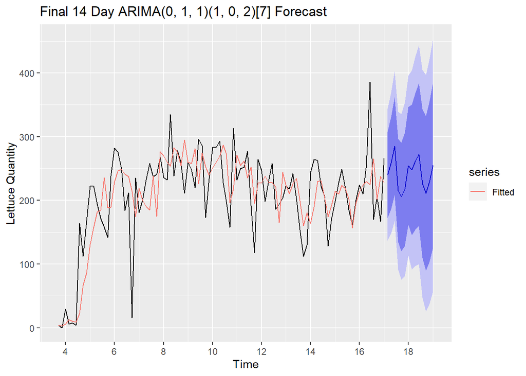

```r
autoplot(forecast_best_arima_20974,
         main = 'Final 14 Day ARIMA(0, 1, 1)(1, 0, 2)[7] Forecast',
         ylab = 'Lettuce Quantity', xlab = 'Time') +
  autolayer(fitted(forecast_best_arima_20974), series = 'Fitted', na.rm=TRUE) +
  scale_x_continuous(breaks = seq(0, 22, by = 2))
```

*Table 3.5:* *This table provides the final prediction value of time series for store 20974.* *Figure 3.4:* *This table provides the final prediction plot for store 20974.*

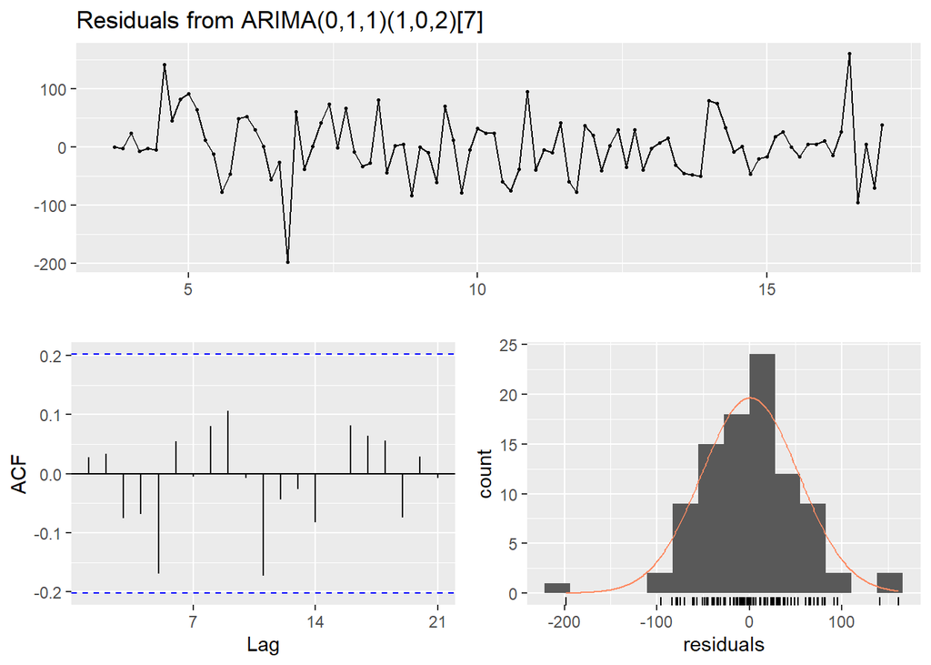

```
##
##  Ljung-Box test
##
## data:  Residuals from ARIMA(0,1,1)(1,0,2)[7]
## Q* = 10.593, df = 10, p-value = 0.3901
##
## Model df: 4.   Total lags used: 14
```

```r
checkresiduals(forecast_best_arima_20974)
```

*Figure 3.5:* *This figure provides the residual and test for store 20974.*

The four tests above indicate that the ARIMA(0, 1, 1)(1, 0, 2)[7] model is a sufficient predictive model.

### Final Forecast for Resturant 20974:

The best two selected model will be compared in this section.

```r
## Checking which model based on RMSE
accuracy_final_model_all_20974 <- rbind(forecast::accuracy(forecast_ets_20974, test_20974),
                                       forecast::accuracy(forecast_arima4_20974, test_20974))
accuracy_final_model_all_20974_df <- data.frame(accuracy_final_model_all_20974,
                                               row.names = c('Train_ets', 'Test_ets', 'Train_ts', 'Test_ts'))

accuracy_final_model_all_20974_df %>%  kable(caption = "Accuracy of Best ETS and ARIMA", align = 'c') %>%
  kable_styling(full_width = F) %>%
  pack_rows("ETS", 1, 2) %>%
  pack_rows("ARIMA(0,1,1)(1,0,2)", 3, 4)
```

Accuracy of Best ETS and ARIMA

|  | ME | RMSE | MAE | MPE | MAPE | MASE | ACF1 | Theil.s.U |
| --- | --- | --- | --- | --- | --- | --- | --- | --- |
| **ETS** |  |  |  |  |  |  |  |  |
| Train_ets | -6.0390230 | 45.29688 | 37.35705 | -Inf | Inf | 0.6524078 | 0.2227129 | NA |
| Test_ets | 28.1729238 | 58.65815 | 35.38409 | 9.464418 | 13.72559 | 0.6179518 | -0.2645748 | 0.8704160 |
| **ARIMA(0,1,1)(1,0,2)** |  |  |  |  |  |  |  |  |
| Train_ts | -0.7632822 | 51.39960 | 38.75011 | -Inf | Inf | 0.6767364 | 0.0338104 | NA |
| Test_ts | 30.2976030 | 58.22247 | 37.72631 | 10.261183 | 14.65342 | 0.6588566 | -0.2346615 | 0.8543104 |

*Table 3.6:* *This Table provides the methods comparison information for store 20974.*

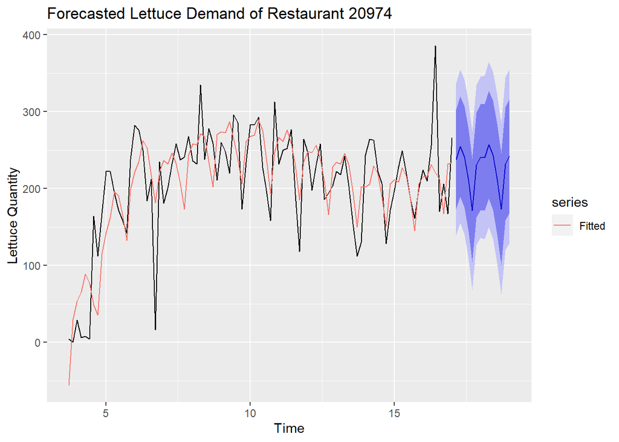

```r
# Best model
final_20974 <- forecast(final_ets_20974, h = 14)

autoplot(final_20974,
         main = 'Forecasted Lettuce Demand of Restaurant 20974',
         ylab = 'Lettuce Quantity',
         xlab = 'Time') +
  autolayer(fitted(final_ets_20974), series = 'Fitted', na.rm=TRUE)
```

```r
#Write to csv
write.csv(final_20974, 'final_20974.csv')

## Final Forecast (Table)
final_20974_1 <- as.data.frame(forecast(final_ets_20974, h = 14))
final_20974_df <- data.frame(final_20974_1$`Point Forecast`,
                                 row.names = c('16/06/15', '17/06/15', '18/06/15', '19/06/15',
                                               '20/06/15', '21/06/15', '22/06/15', '23/06/15',
                                               '24/06/15', '25/06/15', '26/06/15', '27/06/15',
                                               '28/06/15', '29/06/15'))
final_20974_df %>%  kable(caption = "Final 14 Day ARIMA Forecast", align = 'c', col.names = 'Lettuce Demand') %>%  kable_styling(full_width = F)
```

|  | Lettuce Demand |
| --- | --- |
| 16/06/15 | 237.9924 |
| 17/06/15 | 254.8547 |
| 18/06/15 | 241.4441 |
| 19/06/15 | 210.8600 |
| 20/06/15 | 171.3848 |
| 21/06/15 | 230.4058 |
| 22/06/15 | 240.8507 |
| 23/06/15 | 240.5104 |
| 24/06/15 | 257.1850 |
| 25/06/15 | 243.6006 |
| 26/06/15 | 212.8556 |
| 27/06/15 | 173.2316 |
| 28/06/15 | 232.1149 |
| 29/06/15 | 242.4323 |

*Figure 3.6:* *This figure provides the final forecasting plot for store 20974.*  
*Table 3.7:* *This table provides the final forecasting value for store 20974.*

## Statistical Analysis for store 46673

To begin with, splitting the dataset into training set and testing set is a must. By selecting the 8.5:1.5 ratio of splitting the original dataset, we can fit the model and test to see the accuracy for further prediction.

```r
train_46673 <- window(ts_46673, end = c(03,85), frequency = 7)
test_46673 <- window(ts_46673, start = c(03,86))
```

### Holt-Winters Method

```r
## Initial Holt-Winters with exponential smoothing
HW_46673 <- HoltWinters(ts_46673, beta = FALSE)
HW_46673
```

```
## Holt-Winters exponential smoothing without trend and with additive seasonal component.
##
## Call:
## HoltWinters(x = ts_46673, beta = FALSE)
##
## Smoothing parameters:
##  alpha: 0.03976672
##  beta : FALSE
##  gamma: 0.2824188
##
## Coefficients:
##         [,1]
## a  143.30360
## s1  11.09769
## s2  21.38368
## s3  21.19577
## s4 -35.24199
## s5 -60.32213
## s6  23.37609
## s7  45.49321
```

```r
## Initial ETS model with automatic fitting
ETS_46673 <- ets(ts_46673, model = 'ZZZ')
ETS_46673
```

```
## ETS(M,N,A)
##
## Call:
##  ets(y = ts_46673, model = "ZZZ")
##
##   Smoothing parameters:
##     alpha = 1e-04
##     gamma = 1e-04
##
##   Initial states:
##     l = 145.6322
##     s = 26.823 13.9141 30.6986 24.3151 -66.7508 -45.1285
##            16.1285
##
##   sigma:  0.1898
##
##      AIC     AICc      BIC
## 1163.044 1165.435 1189.391
```

We are going to apply the model onto the training and testing set to do the forecasting.

#### Forecasting on Training Set

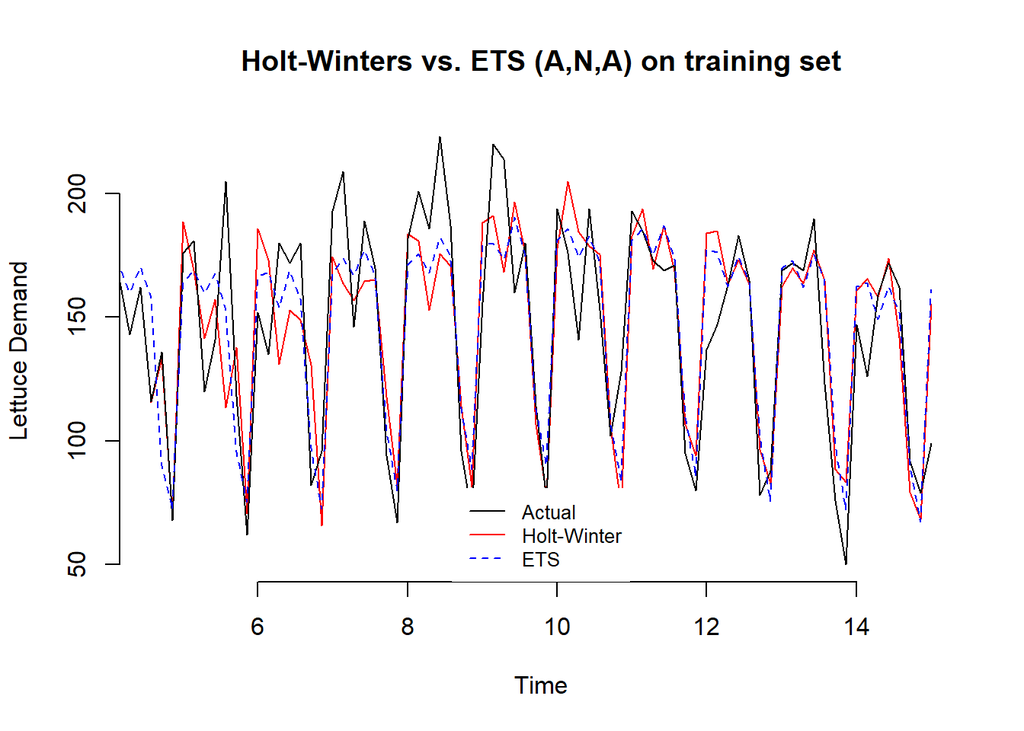

```r
#Holt-Winters
train_HW_46673 <- HoltWinters(train_46673, beta = FALSE)
forecast_HW_46673  <- forecast(train_HW_46673, h = 14)
#ets
train_ets_46673 <- ets(train_46673, model = 'ZZZ')
forecast_ets_46673  <- forecast(train_ets_46673, h = 14)

plot(train_HW_46673, main="Holt-Winters vs. ETS (A,N,A) on training set",
     xlab="Time",
     ylab="Lettuce Demand", lty = 1, col = "black", frame.plot = FALSE)
lines(fitted(train_ets_46673), col = "Blue", lty = 2)
legend("bottom", legend=c("Actual","Holt-Winter", "ETS"), col=c("black", "red", "blue"), box.lty=0, lty=c(1,1,2), cex=0.8)
```

*Figure 4.1:* *This figure provides the fitted lines for holt-winter and ETS on store 46673.*

```r
## Accuracy Comparison
acc_ets_HW_46673 <- rbind(forecast::accuracy(forecast_HW_46673,
                                       test_46673),
                        forecast::accuracy(forecast_ets_46673,
                                 test_46673))

acc_ets_HW_46673_df <- data.frame(acc_ets_HW_46673,
                                row.names = c('HW_on_Train', 'HW_on_Test',
                                              'ETS_on_Train', 'ETS_on_Test'))

acc_ets_HW_46673_df %>%  kable(caption = "Accuracy: Holt-Winter vs. ETS",
                                  align = 'c') %>%
  kable_styling() %>%
  pack_rows("Holt-Winters", 1, 2) %>%
  pack_rows("ETS", 3, 4)
```

Accuracy: Holt-Winter vs. ETS

|  | ME | RMSE | MAE | MPE | MAPE | MASE | ACF1 | Theil.s.U |
| --- | --- | --- | --- | --- | --- | --- | --- | --- |
| **Holt-Winters** |  |  |  |  |  |  |  |  |
| HW_on_Train | -1.147373 | 26.98638 | 20.65720 | -4.093528 | 15.55005 | 0.7700923 | 0.0302290 | NA |
| HW_on_Test | 16.857893 | 36.01673 | 25.40506 | 7.575521 | 17.34396 | 0.9470903 | -0.0016144 | 0.4944488 |
| **ETS** |  |  |  |  |  |  |  |  |
| ETS_on_Train | -1.344239 | 23.09275 | 18.45541 | -4.051058 | 14.34535 | 0.6880102 | 0.0270143 | NA |
| ETS_on_Test | 16.532386 | 31.58514 | 23.35191 | 8.385233 | 15.78179 | 0.8705499 | 0.0546875 | 0.3989143 |

*Table 4.1:* *This table provides the comparison information for store 46673.*

From the table above, since the ETS model has the lowest RMSE value, we are going to select ETS model.

#### Final ETS Model

```r
final_ets_46673 <- forecast(ETS_46673, h = 14)
final_ets_46673_1 <- as.data.frame(forecast(ETS_46673, h = 14))
final_ets_46673_df <- data.frame(final_ets_46673_1$`Point Forecast`,
                     row.names = c('16/06/15', '17/06/15',
                                   '18/06/15', '19/06/15',
                                   '20/06/15', '21/06/15',
                                   '22/06/15','23/06/15',
                                   '24/06/15', '25/06/15',
                                   '26/06/15', '27/06/15',
                                   '28/06/15', '29/06/15'))
final_ets_46673_df %>%
  kable(caption = "14 Day ETS Forecast for Store 46673", align = 'c', col.names = 'Lettuce Demand') %>%
  kable_styling(full_width = F)
```

14 Day ETS Forecast for Store 46673

|  | Lettuce Demand |
| --- | --- |
| 16/06/15 | 159.54815 |
| 17/06/15 | 172.45762 |
| 18/06/15 | 161.76594 |
| 19/06/15 | 100.50529 |
| 20/06/15 | 78.87924 |
| 21/06/15 | 169.94661 |
| 22/06/15 | 176.33227 |
| 23/06/15 | 159.54815 |
| 24/06/15 | 172.45762 |
| 25/06/15 | 161.76594 |
| 26/06/15 | 100.50529 |
| 27/06/15 | 78.87924 |
| 28/06/15 | 169.94661 |
| 29/06/15 | 176.33227 |

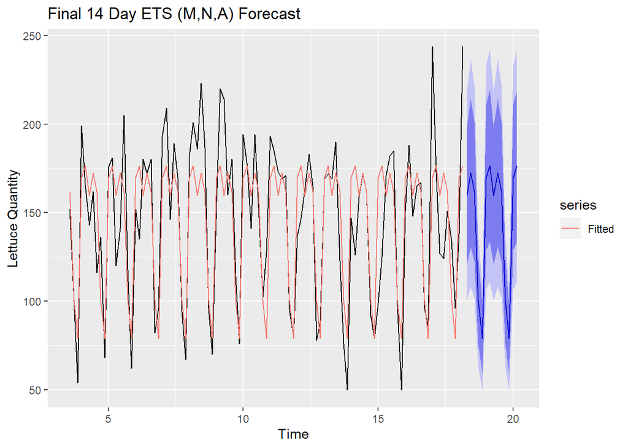

```r
autoplot(final_ets_46673,
         main = 'Final 14 Day ETS (M,N,A) Forecast',
         ylab = 'Lettuce Quantity',
         xlab = 'Time') +
  autolayer(fitted(final_ets_46673),
            series = 'Fitted', na.rm=TRUE)
```

*Table 4.2:* *This table provides the ETS forecasting fitted value for store 46673.*  
*Figure 4.2:* *This figure provides the forecasting plot for store 46673.*

### ARIMA Forecast Models

I then develop the ARIMA model for store 46673 to forecast the demand of lettuce. The ARIMA model will then be compared with the final ETS model above to determine which is the most accuracy model and to do the further forecasting based on the accuracy of the model.

```r
## Testing stationary
adf.test(ts_46673)
```

```
##
##  Augmented Dickey-Fuller Test
##
## data:  ts_46673
## Dickey-Fuller = -8.4973, Lag order = 4, p-value = 0.01
## alternative hypothesis: stationary
```

```r
kpss.test(ts_46673, null = 'Trend')
```

```
##
##  KPSS Test for Trend Stationarity
##
## data:  ts_46673
## KPSS Trend = 0.10896, Truncation lag parameter = 4, p-value = 0.1
```

```r
pp.test(ts_46673)
```

```
##
##  Phillips-Perron Unit Root Test
##
## data:  ts_46673
## Dickey-Fuller Z(alpha) = -55.097, Truncation lag parameter = 4, p-value
## = 0.01
## alternative hypothesis: stationary
```

```r
ndiffs(ts_46673)
```

```
## [1] 0
```

```r
nsdiffs(ts_46673)
```

```
## [1] 1
```

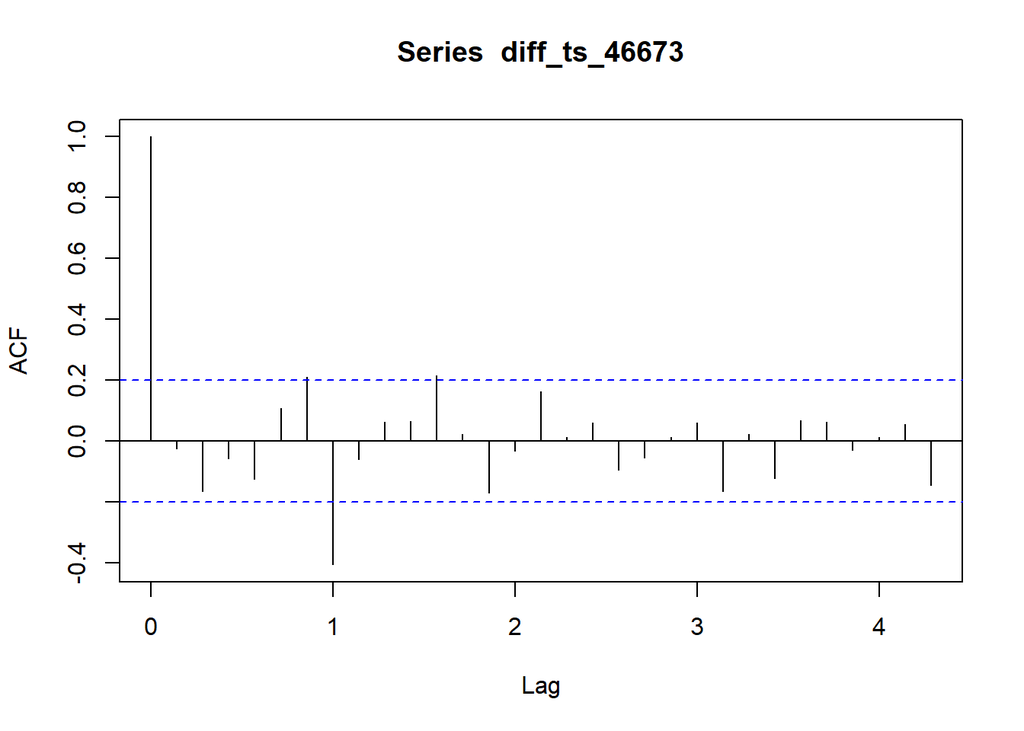

```r
diff_ts_46673 <- diff(ts_46673, lag = 7, differences = 1)
acf(diff_ts_46673, lag.max = 30)
```

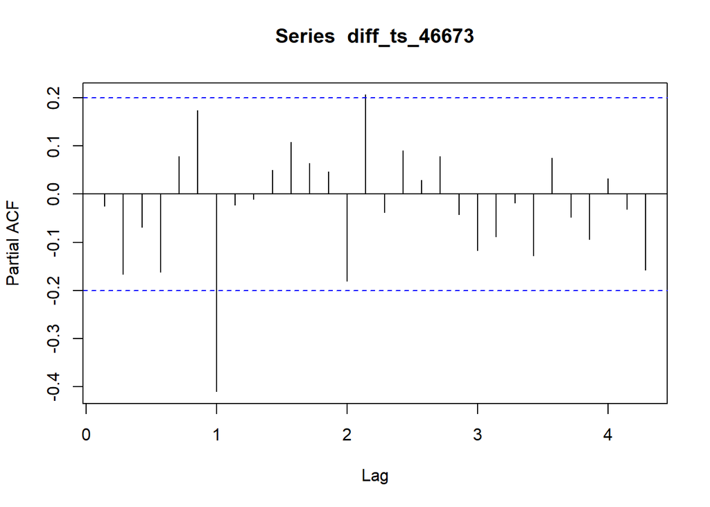

```r
pacf(diff_ts_46673, lag.max = 30)
```

*Figure 4.3:* *This figure provides the ACF and PACF information for store 46673.*

Then I applied one seasonal difference and plotting the ACF and PACF plot. Table below indicates the best model as ARIMA(0,0,1)(2,1,0)[7].

```r
auto.arima(ts_46673, trace = TRUE, ic = 'aic', approximation = FALSE)
```

```
##
##  ARIMA(2,0,2)(1,1,1)[7] with drift         : Inf
##  ARIMA(0,0,0)(0,1,0)[7] with drift         : 959.4565
##  ARIMA(1,0,0)(1,1,0)[7] with drift         : 942.2525
##  ARIMA(0,0,1)(0,1,1)[7] with drift         : Inf
##  ARIMA(0,0,0)(0,1,0)[7]                    : 957.4687
##  ARIMA(1,0,0)(0,1,0)[7] with drift         : 961.3931
##  ARIMA(1,0,0)(2,1,0)[7] with drift         : 935.2912
##  ARIMA(1,0,0)(2,1,1)[7] with drift         : Inf
##  ARIMA(1,0,0)(1,1,1)[7] with drift         : Inf
##  ARIMA(0,0,0)(2,1,0)[7] with drift         : 936.0419
##  ARIMA(2,0,0)(2,1,0)[7] with drift         : 935.904
##  ARIMA(1,0,1)(2,1,0)[7] with drift         : 935.8839
##  ARIMA(0,0,1)(2,1,0)[7] with drift         : 934.403
##  ARIMA(0,0,1)(1,1,0)[7] with drift         : 942.0057
##  ARIMA(0,0,1)(2,1,1)[7] with drift         : Inf
##  ARIMA(0,0,1)(1,1,1)[7] with drift         : Inf
##  ARIMA(0,0,2)(2,1,0)[7] with drift         : 935.7928
##  ARIMA(1,0,2)(2,1,0)[7] with drift         : Inf
##  ARIMA(0,0,1)(2,1,0)[7]                    : 932.6298
##  ARIMA(0,0,1)(1,1,0)[7]                    : 940.1299
##  ARIMA(0,0,1)(2,1,1)[7]                    : Inf
##  ARIMA(0,0,1)(1,1,1)[7]                    : Inf
##  ARIMA(0,0,0)(2,1,0)[7]                    : 934.2306
##  ARIMA(1,0,1)(2,1,0)[7]                    : 934.114
##  ARIMA(0,0,2)(2,1,0)[7]                    : 934.0247
##  ARIMA(1,0,0)(2,1,0)[7]                    : 933.5042
##  ARIMA(1,0,2)(2,1,0)[7]                    : Inf
##
##  Best model: ARIMA(0,0,1)(2,1,0)[7]
```

```
## Series: ts_46673
## ARIMA(0,0,1)(2,1,0)[7]
##
## Coefficients:
##          ma1     sar1     sar2
##       0.2526  -0.6856  -0.3802
## s.e.  0.1279   0.1118   0.1171
##
## sigma^2 estimated as 881.2:  log likelihood=-462.31
## AIC=932.63   AICc=933.07   BIC=942.89
```

#### ARIMA Functions Selected

The best model is determined to be ARIMA(0,0,1)(2,1,0)[7], and the second best is ARIMA(1,0,0)(2,1,0)[7], which indicates that we can put ARIMA(p,0,q)(2,1,0) with period 7 into the pool.

```r
arima1_46673 <- Arima(ts_46673, order = c(0, 0 ,1), seasonal = list(order = c(2, 1, 0), period = 7))
arima2_46673 <- Arima(ts_46673, order = c(0, 0 ,2), seasonal = list(order = c(2, 1, 0), period = 7))
arima3_46673 <- Arima(ts_46673, order = c(1, 0 ,0), seasonal = list(order = c(2, 1, 0), period = 7))
arima4_46673 <- Arima(ts_46673, order = c(1, 0 ,1), seasonal = list(order = c(2, 1, 0), period = 7))
arima5_46673 <- Arima(ts_46673, order = c(1, 0 ,2), seasonal = list(order = c(2, 1, 0), period = 7))
```

The forecast function is used on each ARIMA model and used with a 14 period forecast.

```r
# 14 day ARIMA forecast
forecast_arima1_46673 <- forecast(arima1_46673, h = 14)
forecast_arima2_46673 <- forecast(arima2_46673, h = 14)
forecast_arima3_46673 <- forecast(arima3_46673, h = 14)
forecast_arima4_46673 <- forecast(arima4_46673, h = 14)
forecast_arima5_46673 <- forecast(arima5_46673, h = 14)
```

```r
accuracy_arima_46673 <- rbind(forecast::accuracy(forecast_arima1_46673), forecast::accuracy(forecast_arima2_46673), forecast::accuracy(forecast_arima3_46673),
           forecast::accuracy(forecast_arima4_46673), forecast::accuracy(forecast_arima5_46673))

accuracy_arima_46673_k <- data.frame(accuracy_arima_46673,
                                     row.names = c('ARIMA(0,0,1)(2,1,0)',
                                                   'ARIMA(0,0,2)(2,1,0)',
                                                   'ARIMA(1,0,0)(2,1,0)',
                                                   'ARIMA(1,0,1)(2,1,0)',
                                                   'ARIMA(1,0,2)(2,1,0)'))
accuracy_arima_46673_k %>%  kable(caption = "Accuracy of ARIMA Model", align = 'c') %>%  kable_styling(full_width = F)
```

Accuracy of ARIMA Model

|  | ME | RMSE | MAE | MPE | MAPE | MASE | ACF1 |
| --- | --- | --- | --- | --- | --- | --- | --- |
| ARIMA(0,0,1)(2,1,0) | 1.214247 | 28.20770 | 20.48348 | -1.963970 | 14.99713 | 0.7315527 | -0.0157945 |
| ARIMA(0,0,2)(2,1,0) | 1.238766 | 28.15855 | 20.42224 | -1.904208 | 15.02200 | 0.7293658 | 0.0017531 |
| ARIMA(1,0,0)(2,1,0) | 1.195277 | 28.37546 | 20.79562 | -2.028033 | 15.21861 | 0.7427008 | 0.0240593 |
| ARIMA(1,0,1)(2,1,0) | 1.229492 | 28.15115 | 20.44910 | -1.930626 | 15.04124 | 0.7303249 | -0.0027605 |
| ARIMA(1,0,2)(2,1,0) | 1.202136 | 27.91864 | 20.39274 | -2.002409 | 15.08251 | 0.7283121 | -0.0097046 |

*Table 4.3:* *This table provides the model pool information for store 46673.*

```r
#Training arima
training_arima1_46673 <- arima(train_46673,
                                    order = c(0, 0 ,1),
                                    seasonal = list(order = c(2, 1, 0),
                                                    period = 7))
training_arima2_46673 <- arima(train_46673,
                                    order = c(0, 0 ,2),
                                    seasonal = list(order = c(2, 1, 0),
                                                    period = 7))
training_arima4_46673 <- arima(train_46673,
                                    order = c(1, 0 ,1),
                                    seasonal = list(order = c(2, 1, 0),
                                                    period = 7))

## Forecast using the training set
forecast_arima1_46673 <- forecast(training_arima1_46673, h = 19)
forecast_arima2_46673 <- forecast(training_arima2_46673, h = 19)
forecast_arima4_46673 <- forecast(training_arima4_46673, h = 19)
```

```r
accuracy_final_arima_46673 <- rbind(accuracy(forecast_arima1_46673,
                                            test_46673),
                              accuracy(forecast_arima2_46673,
                                       test_46673),
                              accuracy(forecast_arima4_46673,
                                       test_46673))

accuracy_final_arima_46673_k <- data.frame(accuracy_final_arima_46673,
                                          row.names = c('Train_1', 'Test_1',
                                                        'Train_2', 'Test_2',
                                                        'Train_4', 'Test_4'))

accuracy_final_arima_46673_k %>%  kable(caption = "Accuracy of ARIMA Models", align = 'c') %>%  kable_styling(full_width = F) %>%
  pack_rows("ARIMA(0,0,1)(2,1,0)", 1, 2) %>%
  pack_rows("ARIMA(0,0,2)(2,1,0)", 3, 4) %>%
  pack_rows("ARIMA(1,0,1)(2,1,0))", 5, 6)
```

Accuracy of ARIMA Models

|  | ME | RMSE | MAE | MPE | MAPE | MASE | ACF1 | Theil.s.U |
| --- | --- | --- | --- | --- | --- | --- | --- | --- |
| **ARIMA(0,0,1)(2,1,0)** |  |  |  |  |  |  |  |  |
| Train_1 | -1.227253 | 25.19315 | 18.79845 | -3.378775 | 14.10903 | 0.7007985 | 0.0057858 | NA |
| Test_1 | 11.144149 | 38.13676 | 27.81503 | 4.098521 | 19.48147 | 1.0369331 | 0.2009951 | 0.5453828 |
| **ARIMA(0,0,2)(2,1,0)** |  |  |  |  |  |  |  |  |
| Train_2 | -1.207221 | 25.16237 | 18.73788 | -3.359508 | 14.02088 | 0.6985406 | 0.0009647 | NA |
| Test_2 | 11.332596 | 38.09466 | 27.83578 | 4.233482 | 19.48065 | 1.0377065 | 0.1982541 | 0.5445366 |
| **ARIMA(1,0,1)(2,1,0))** |  |  |  |  |  |  |  |  |
| Train_4 | -1.213205 | 25.17449 | 18.76535 | -3.367281 | 14.06086 | 0.6995647 | 0.0020536 | NA |
| Test_4 | 11.258745 | 38.09786 | 27.81180 | 4.179484 | 19.47510 | 1.0368128 | 0.1997747 | 0.5446505 |

*Table 4.4:* *This table provides the model comparison information for store 46673.*

#### Final ARIMA Model

```r
## Best model plotted
best_arima_46673_a <- arima(ts_46673,
                               order = c(0, 0 ,2),
                               seasonal = list(order = c(2, 1, 0),
                                               period = 7))
best_arima_46673_b <- arima(ts_46673,
                               order = c(1, 0 ,1),
                               seasonal = list(order = c(2, 1, 0),
                                               period = 7))
```

Since the RMSE for this two time series models are so close, we keep these two models at this stage and compared with the holt-winter method.

```r
## model a
forecast_best_arima_46673_a <- forecast(best_arima_46673_a, h = 14)
forecast_best_arima_46673_a_1 <- as.data.frame(forecast_best_arima_46673_a)

forecast_best_arima_46673_a_df <- data.frame(forecast_best_arima_46673_a_1$`Point Forecast`,
                                               row.names = c('16/06/15', '17/06/15', '18/06/15',
                                                             '19/06/15', '20/06/15', '21/06/15',
                                                             '22/06/15', '23/06/15', '24/06/15',
                                                             '25/06/15', '26/06/15', '27/06/15',
                                                             '28/06/15', '29/06/15'))
forecast_best_arima_46673_a_df %>%  kable(caption = "Final 14 Day ARIMA Forecast", align = 'c',  col.names = 'Lettuce Demand') %>%  kable_styling(full_width = F)
```

Final 14 Day ARIMA Forecast

|  | Lettuce Demand |
| --- | --- |
| 16/06/15 | 171.78898 |
| 17/06/15 | 148.96816 |
| 18/06/15 | 168.17786 |
| 19/06/15 | 109.69830 |
| 20/06/15 | 76.14051 |
| 21/06/15 | 173.56386 |
| 22/06/15 | 202.74601 |
| 23/06/15 | 150.01766 |
| 24/06/15 | 147.62954 |
| 25/06/15 | 162.75694 |
| 26/06/15 | 111.70363 |
| 27/06/15 | 85.54012 |
| 28/06/15 | 189.20379 |
| 29/06/15 | 203.75710 |

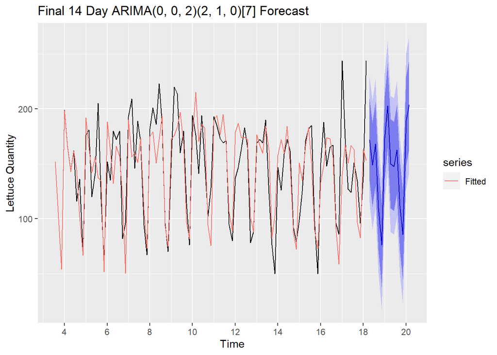

```r
autoplot(forecast_best_arima_46673_a,
         main = 'Final 14 Day ARIMA(0, 0, 2)(2, 1, 0)[7] Forecast',
         ylab = 'Lettuce Quantity', xlab = 'Time') +
  autolayer(fitted(forecast_best_arima_46673_a), series = 'Fitted', na.rm=TRUE) +
  scale_x_continuous(breaks = seq(0, 22, by = 2))
```

*Table 4.5.a:* *This table provides the final prediction value of time series for store 46673.* *Figure 4.4.a:* *This table provides the final prediction plot for store 46673.*

```r
## model b
forecast_best_arima_46673_b <- forecast(best_arima_46673_b, h = 14)
forecast_best_arima_46673_b_1 <- as.data.frame(forecast_best_arima_46673_b)

forecast_best_arima_46673_b_df <- data.frame(forecast_best_arima_46673_b_1$`Point Forecast`,
                                               row.names = c('16/06/15', '17/06/15', '18/06/15',
                                                             '19/06/15', '20/06/15', '21/06/15',
                                                             '22/06/15', '23/06/15', '24/06/15',
                                                             '25/06/15', '26/06/15', '27/06/15',
                                                             '28/06/15', '29/06/15'))
forecast_best_arima_46673_b_df %>%  kable(caption = "Final 14 Day ARIMA Forecast", align = 'c',  col.names = 'Lettuce Demand') %>%  kable_styling(full_width = F)
```

Final 14 Day ARIMA Forecast

|  | Lettuce Demand |
| --- | --- |
| 16/06/15 | 172.54290 |
| 17/06/15 | 151.63795 |
| 18/06/15 | 170.16535 |
| 19/06/15 | 108.95802 |
| 20/06/15 | 75.79663 |
| 21/06/15 | 173.41109 |
| 22/06/15 | 202.33175 |
| 23/06/15 | 150.12213 |
| 24/06/15 | 148.75042 |
| 25/06/15 | 163.44768 |
| 26/06/15 | 111.25219 |
| 27/06/15 | 85.48220 |
| 28/06/15 | 189.98949 |
| 29/06/15 | 203.20197 |